# CoreTrace - Análise exploratória v2

## 1 Objetivo

Nesta análise, observamos o uso dos recursos de dez servidores em uma simulação de delivery. Queremos entender quando aparecem alertas, como eles mudam durante a semana e quais informações ajudam a investigar cada situação.

Também buscamos explicar a escolha das métricas do CoreTrace e como os indicadores e gráficos podem ajudar quem acompanha os servidores.

Os dados são simulados. Por isso, as conclusões valem para este cenário. Para saber se um alerta afetou pedidos ou pagamentos, também seriam necessários dados da aplicação.

## 2 Contexto do cenário

O cenário acompanha sete dias de uma operação de delivery, entre 12 e 19 de outubro de 2026. O último horário é 20h30 do dia 19, durante o aumento de uso dos recursos no jantar. Há um registro por minuto para cada servidor.

Os dez servidores estão divididos em três perfis, de acordo com a função de cada serviço:

- **Carrinho:** quatro servidores responsáveis pelos serviços de montagem e finalização de pedidos.
- **Financeiro:** três servidores responsáveis pelos serviços de pagamentos e transações.
- **Catálogo:** três servidores responsáveis por consultas e disponibilização de dados de produtos.

Durante a semana simulada, alguns servidores apresentam aumento no uso de CPU e memória, enquanto outros registram erros e descartes de pacotes na rede. Parte desses episódios termina com o retorno das métricas aos níveis normais. Esse histórico permite comparar os períodos com e sem alertas, identificar problemas que se repetem e acompanhar como cada episódio começa, se agrava e se recupera.

Às 20h30, há dois servidores críticos, dois em atenção e seis normais. Os quatro servidores afetados têm seis alertas ativos, porque um servidor pode ter alertas em mais de um componente. Há também um volume cujo uso cresce durante a semana, mesmo sem chegar ao limite de atenção. Esse caso será usado na previsão de capacidade.

O iFood é usado como referência de contexto. Os servidores e os dados são fictícios e não representam a estrutura real da empresa.

## 3 Preparação e leitura dos dados

Os dados foram gerados pela simulação do site e salvos em CSV. A análise usa o histórico da semana, o cadastro dos servidores, os limites de alerta, os volumes e as listas de processos e containers.

```r
# Pasta com os arquivos exportados pelo site.
pasta_csv = "../../website/scripts/exportados/analise"

# Lê um dos arquivos dessa pasta.
ler_arquivo_csv = function(nome_arquivo) {
  read.csv(file.path(pasta_csv, nome_arquivo), stringsAsFactors = FALSE,
           fileEncoding = "UTF-8", na.strings = "")
}

historico_servidores = ler_arquivo_csv("historico-semana.csv")
cadastro_servidores = ler_arquivo_csv("servidores.csv")
limites_alerta = ler_arquivo_csv("limites.csv")
historico_volumes = ler_arquivo_csv("volumes-historico.csv")
processos_atuais = ler_arquivo_csv("processos-finais.csv")
containers_atuais = ler_arquivo_csv("containers-finais.csv")

# Converte o texto dos horários para data e hora de Brasília.
converter_horario = function(texto) {
  as.POSIXct(texto, format = "%Y-%m-%d %H:%M:%S", tz = "America/Sao_Paulo")
}

cadastro_servidores$mac = cadastro_servidores$ENDERECO_MAC
cadastro_servidores$docker = tolower(as.character(cadastro_servidores$docker_monitorado)) == "true"
historico_servidores$mac = historico_servidores$ENDERECO_MAC
historico_servidores$instante = converter_horario(historico_servidores$TIMESTAMP)
historico_servidores = historico_servidores[order(historico_servidores$mac, historico_servidores$instante), ]
rownames(historico_servidores) = NULL

inicio_semana = converter_horario("2026-10-12 20:30:00")
horario_final = converter_horario("2026-10-19 20:30:00")
horarios_semana = seq(inicio_semana, horario_final, by = "1 min")
periodos = c("30 minutos" = 30, "1 hora" = 60, "6 horas" = 360,
             "12 horas" = 720, "24 horas" = 1440, "7 dias" = 10080)
perfis_analisados = c("Todos", "Carrinho", "Financeiro", "Catálogo")
metricas_alerta = c("cpu_percent", "ram_percent", "disk_percent", "net_errors", "net_drops")

# Acrescenta nome, perfil e horário às tabelas de detalhe.
adicionar_cadastro = function(tabela) {
  tabela$mac = tabela$ENDERECO_MAC
  tabela$instante = converter_horario(tabela$TIMESTAMP)
  posicao_cadastro = match(tabela$mac, cadastro_servidores$mac)
  if (any(is.na(posicao_cadastro))) stop("Há um MAC que não pertence ao cadastro.")
  tabela$servidor = cadastro_servidores$servidor[posicao_cadastro]
  tabela$perfil = cadastro_servidores$perfil[posicao_cadastro]
  tabela
}
historico_volumes = adicionar_cadastro(historico_volumes)
processos_atuais = adicionar_cadastro(processos_atuais)
containers_atuais = adicionar_cadastro(containers_atuais)
volumes_finais = historico_volumes[historico_volumes$instante == horario_final, ]
```

## 4 Organização dos servidores e das observações

A base contém dez servidores, divididos entre Carrinho, Financeiro e Catálogo. Cada linha do histórico representa um servidor em um minuto. Os volumes ficam em uma tabela separada, pois um servidor pode ter mais de um volume. Processos e containers representam o instante final, às 20h30.

```r
knitr::kable(cadastro_servidores[c("servidor", "mac", "perfil", "cpu_logicas",
                        "ram_total_gb", "swap_total_gb", "docker")])
```

| servidor | mac | perfil | cpu_logicas | ram_total_gb | swap_total_gb | docker |
| --- | --- | --- | --- | --- | --- | --- |
| cart-api-07 | AA:BB:CC:DD:EE:07 | Carrinho | 8 | 16 | 4 | TRUE |
| cart-api-12 | AA:BB:CC:DD:EE:12 | Carrinho | 8 | 16 | 4 | TRUE |
| cart-api-02 | AA:BB:CC:DD:EE:02 | Carrinho | 8 | 16 | 4 | TRUE |
| cart-api-09 | AA:BB:CC:DD:EE:09 | Carrinho | 8 | 16 | 4 | TRUE |
| pay-db-02 | AA:BB:CC:DD:EF:02 | Financeiro | 8 | 32 | 8 | TRUE |
| pay-api-04 | AA:BB:CC:DD:EF:04 | Financeiro | 8 | 16 | 4 | TRUE |
| pay-api-06 | AA:BB:CC:DD:EF:06 | Financeiro | 8 | 16 | 4 | TRUE |
| catalog-api-03 | AA:BB:CC:DD:F0:03 | Catálogo | 8 | 16 | 4 | FALSE |
| catalog-api-05 | AA:BB:CC:DD:F0:05 | Catálogo | 8 | 64 | 8 | FALSE |
| catalog-api-08 | AA:BB:CC:DD:F0:08 | Catálogo | 8 | 16 | 4 | FALSE |

```r
table(cadastro_servidores$perfil)
```

```
##
##   Carrinho   Catálogo Financeiro
##          4          3          3
```

```r
knitr::kable(head(historico_servidores[c("servidor", "instante", metricas_alerta)]), digits = 2)
```

| servidor | instante | cpu_percent | ram_percent | disk_percent | net_errors | net_drops |
| --- | --- | --- | --- | --- | --- | --- |
| cart-api-02 | 2026-10-12 20:30:00 | 55.41 | 64.71 | 53.72 | 0.21 | 0.68 |
| cart-api-02 | 2026-10-12 20:31:00 | 55.42 | 64.67 | 53.72 | 0.21 | 0.68 |
| cart-api-02 | 2026-10-12 20:32:00 | 55.44 | 64.63 | 53.72 | 0.21 | 0.68 |
| cart-api-02 | 2026-10-12 20:33:00 | 55.46 | 64.58 | 53.72 | 0.20 | 0.67 |
| cart-api-02 | 2026-10-12 20:34:00 | 55.47 | 64.54 | 53.72 | 0.20 | 0.67 |
| cart-api-02 | 2026-10-12 20:35:00 | 55.49 | 64.49 | 53.72 | 0.20 | 0.67 |

## 5 Qualidade dos dados

Antes dos cálculos, observamos a quantidade de registros, os valores ausentes e os horários repetidos. Um campo vazio não é tratado como zero. O histórico cobre sete dias com 10.081 registros por servidor, incluindo o primeiro e o último minuto.

```r
resumo_dados = data.frame(
  informacao = c("Servidores", "Registros no histórico", "Horários repetidos", "Valores ausentes nas métricas de alerta"),
  quantidade = c(nrow(cadastro_servidores), nrow(historico_servidores),
    sum(duplicated(historico_servidores[c("mac", "instante")])), sum(is.na(historico_servidores[metricas_alerta]))))
knitr::kable(resumo_dados)
```

| informacao | quantidade |
| --- | --- |
| Servidores | 10 |
| Registros no histórico | 100810 |
| Horários repetidos | 0 |
| Valores ausentes nas métricas de alerta | 0 |

```r
# Interrompe a análise se faltar uma métrica usada nos alertas.
if (any(is.na(historico_servidores[metricas_alerta]))) stop("Há valores ausentes nas métricas de alerta.")
if (any(is.na(historico_servidores$instante))) stop("Há horários que não puderam ser lidos.")
if (any(duplicated(cadastro_servidores$mac))) stop("Há MACs repetidos no cadastro.")
if (any(is.na(match(historico_servidores$mac, cadastro_servidores$mac)))) stop("Há MACs fora do cadastro.")

for (metrica_atual in metricas_alerta) {
  if (!is.numeric(historico_servidores[[metrica_atual]])) stop(paste("A coluna precisa ser numérica:", metrica_atual))
  if (any(!is.finite(historico_servidores[[metrica_atual]]) |
          historico_servidores[[metrica_atual]] < 0)) {
    stop(paste("Valor inválido em", metrica_atual))
  }
}
for (metrica_atual in c("cpu_percent", "ram_percent", "disk_percent", "swap_percent")) {
  if (any(is.na(historico_servidores[[metrica_atual]]) | historico_servidores[[metrica_atual]] < 0 | historico_servidores[[metrica_atual]] > 100)) {
    stop(paste("Percentual inválido em", metrica_atual))
  }
}

for (mac_atual in cadastro_servidores$mac) {
  dados_servidor = historico_servidores[historico_servidores$mac == mac_atual, ]
  if (nrow(dados_servidor) != length(horarios_semana)) stop("Quantidade de registros diferente por servidor.")
  if (any(duplicated(dados_servidor$instante))) stop("Há horários repetidos.")
  if (any(as.numeric(dados_servidor$instante) != as.numeric(horarios_semana))) stop("Há minutos faltando ou fora da semana.")
}
knitr::kable(as.data.frame(table(historico_servidores$servidor)))
```

| Var1 | Freq |
| --- | --- |
| cart-api-02 | 10081 |
| cart-api-07 | 10081 |
| cart-api-09 | 10081 |
| cart-api-12 | 10081 |
| catalog-api-03 | 10081 |
| catalog-api-05 | 10081 |
| catalog-api-08 | 10081 |
| pay-api-04 | 10081 |
| pay-api-06 | 10081 |
| pay-db-02 | 10081 |

## 6 Definição das métricas

O dicionário mostra as opções do catálogo de monitoramento. As métricas foram organizadas por recurso para explicar o que cada medida representa, sua unidade e o nível de detalhamento necessário pra análise.

Separamos medidas de uso dos recursos, sinais de espera e registros de problemas. Para entender um alerta, precisamos olhar o histórico e outras informações do servidor. Uma medida sozinha não explica a causa.

### 6.1 CPU

As métricas de CPU permitem observar a utilização do processamento e investigar diferenças entre CPUs lógicas e os tipos de atividade.

| Métrica | Unidade | Finalidade |
| --- | --- | --- |
| Uso total de CPU | % | Acompanhar a utilização do processamento do servidor |
| Uso por CPU lógica | % por CPU lógica | Identificar concentração de utilização que a média total pode esconder |
| CPU em modo usuário | % | Observar a parcela de tempo dedicada à execução em modo usuário |
| CPU em modo sistema | % | Observar a parcela de tempo dedicada à execução em modo kernel |
| CPU ociosa | % | Observar a parcela de tempo em que a CPU permanece ociosa |
| Espera por I/O | % | Apoiar a investigação de espera associada a operações de entrada e saída |
| Frequência da CPU | MHz | Acrescentar contexto sobre a frequência de operação |
| Interrupções | eventos/s | Acompanhar a atividade de interrupções do sistema |
| Trocas de contexto | eventos/s | Acompanhar a alternância de execução entre tarefas |

A CPU total mostra o uso do servidor como um todo. O uso por CPU lógica mostra como esse trabalho se divide. Em processos e containers, 100% pode representar uma CPU lógica. Nesse caso, um consumidor que usa várias CPUs pode passar de 100%.

### 6.2 Carga do sistema

A carga média ajuda a entender quanto trabalho está sendo executado ou aguardando atendimento no servidor. No Linux, considera tanto tarefas executando ou aguardando CPU quanto tarefas em determinados estados de espera, como operações de disco. Por isso, carga alta não significa necessariamente CPU muito utilizada. O servidor pode ter várias tarefas esperando pelo disco, por exemplo, enquanto a CPU ainda tem capacidade disponível. Essa métrica deve ser interpretada junto ao uso de CPU e às métricas de I/O.

| Métrica | Unidade | Finalidade |
| --- | --- | --- |
| Carga média de 1 minuto | carga | Observar mudanças mais recentes na demanda |
| Carga média de 5 minutos | carga | Acompanhar a persistência da demanda |
| Carga média de 15 minutos | carga | Comparar o comportamento recente com uma janela mais longa |

A carga não é um percentual. Para entendê-la, também olhamos a quantidade de CPUs lógicas e os sinais de CPU e disco.

### 6.3 Memória RAM

As métricas de RAM permitem observar ocupação, capacidade e margem disponível, além de ocorrências de encerramento por falta de memória.

| Métrica | Unidade | Finalidade |
| --- | --- | --- |
| Uso de RAM | % | Acompanhar a ocupação em relação à capacidade |
| Capacidade total de RAM | GB | Entender o percentual junto da quantidade em GB |
| Memória disponível | GB | Observar a estimativa de memória disponível para novas demandas |
| Memória em uso | GB | Mostrar a memória em uso conforme a definição da fonte |
| Memória livre | GB | Observar a memória não utilizada, distinguindo-a da disponível |
| Memória em cache | GB | Acrescentar contexto sobre o uso de memória para cache |
| Encerramentos por OOM | ocorrências no intervalo | Identificar novos encerramentos por falta de memória registrados pela fonte |

Memória livre e memória disponível não são equivalentes. Não se deve assumir que memória em uso + memória disponível sempre corresponde à capacidade total.

### 6.4 Swap

A análise de swap complementa a observação da RAM, distinguindo ocupação de movimentação de dados.

| Métrica | Unidade | Finalidade |
| --- | --- | --- |
| Uso de swap | % | Acompanhar a proporção ocupada |
| Entrada de swap | bytes/s | Observar dados trazidos da swap para a RAM |
| Saída de swap | bytes/s | Observar dados enviados da RAM para a swap |
| Swap em uso | GB | Mostrar o espaço ocupado |
| Swap livre | GB | Mostrar o espaço restante |

A ocupação da swap pode permanecer após um período de maior demanda e, sozinha, não indica falta de RAM no momento. Pra investigar pressão de memória, analisamos também a memória disponível e a movimentação de dados entre RAM e swap ao longo do tempo. Quando não houver swap configurada, essa condição será informada explicitamente.

### 6.5 Capacidade e atividade de armazenamento

Analisamos o espaço ocupado por volume, como `/dados`. Já as leituras e escritas são apresentadas por dispositivo. É preciso conhecer a relação entre eles antes de tratar os dois como a mesma coisa.

| Métrica | Unidade | Detalhamento | Finalidade |
| --- | --- | --- | --- |
| Ocupação do volume | % | Volume | Acompanhar o consumo da capacidade |
| Espaço livre | GB | Volume | Mostrar a margem restante |
| Espaço ocupado | GB | Volume | Mostrar o armazenamento utilizado |
| Uso de inodes | % | Sistema de arquivos aplicável | Observar o consumo da capacidade de manter arquivos |
| Tempo médio estimado de leitura e escrita | ms | Dispositivo e operação | Investigar o tempo médio das operações de I/O |
| Fila média de I/O | operações | Dispositivo | Acompanhar operações pendentes e em andamento conforme a fonte |
| Taxa de leitura | bytes/s | Dispositivo | Mostrar o volume de dados lidos por segundo |
| Taxa de escrita | bytes/s | Dispositivo | Mostrar o volume de dados escritos por segundo |
| Operações de leitura | IOPS | Dispositivo | Mostrar leituras por segundo |
| Operações de escrita | IOPS | Dispositivo | Mostrar escritas por segundo |

A capacidade total do volume também será registrada como informação de referência.

Espaço disponível e desempenho de I/O respondem a perguntas diferentes: um volume pode ter espaço livre e apresentar operações lentas. O tempo médio estimado de I/O não corresponde à latência de uma requisição da aplicação.

### 6.6 Rede

As métricas de rede são identificadas por interface e, quando aplicável, pela direção de recebimento ou envio.

| Métrica | Unidade | Finalidade |
| --- | --- | --- |
| Dados recebidos e enviados | bytes/s | Acompanhar o tráfego em cada direção |
| Erros de recebimento e envio | eventos/s | Localizar ocorrências de erro na comunicação |
| Descartes na entrada e saída | pacotes/s | Acompanhar pacotes descartados |
| Estado da interface | ativa/inativa | Identificar o estado operacional informado pela fonte |
| Pacotes recebidos | pacotes/s | Acompanhar a quantidade de pacotes recebidos |
| Pacotes enviados | pacotes/s | Acompanhar a quantidade de pacotes enviados |

Tráfego em bytes/s não representa percentual de utilização sem uma capacidade de referência. Erros e descartes exigem investigação e não comprovam, isoladamente, perda de pedidos ou falha de pagamento.

### 6.7 Processos e containers

Os processos e containers mostram quais programas estão usando os recursos do servidor.

| Objeto | Medidas e informações | Finalidade |
| --- | --- | --- |
| Processo | PID, nome, estado, CPU e RAM | Identificar consumidores de recursos dentro do servidor |
| Container | Identificação, estado, CPU, RAM e atividade de I/O | Investigar a distribuição do consumo entre containers |

No cenário, o monitoramento Docker se aplica aos perfis Carrinho e Financeiro. No perfil Catálogo, a informação deve aparecer como “Não monitorado”.

Um processo pode estar dentro de um container. Por isso, somar o consumo dos dois pode contar parte do uso duas vezes.

### 6.8 Indicadores calculados para a dashboard

Os indicadores são calculados com os valores das métricas, o cadastro e os limites de alerta.

| Indicador | Definição |
| --- | --- |
| Servidores em atenção no período | Servidores cuja maior gravidade dentro do intervalo é atenção |
| Servidores críticos no período | Servidores cuja maior gravidade dentro do intervalo é crítica |
| Alertas do período | Episódios por servidor e componente ativos em algum trecho da janela |
| Alertas ativos | Condições por servidor e componente ainda abertas às 20h30 |
| Evolução dos servidores em alerta | Contagem de servidores em atenção e críticos em cada instante |
| Servidores com alertas por recurso | Contagem de servidores distintos afetados em cada recurso, conforme a referência temporal definida |
| Previsão de capacidade | Prazo estimado até um limite de ocupação, considerando o histórico e a hipótese de crescimento adotada |

Cards e barras da geral usam o período selecionado. As condições ativas e os valores atuais do detalhe usam o instante final. A previsão da geral usa o filtro; a previsão do detalhe usa a semana inteira.

### 6.9 Como escolhemos as métricas essenciais

Consideramos essencial uma métrica que faz falta para responder a uma pergunta importante da proposta do CoreTrace. Também observamos se ela pode ser calculada com outros campos e se faz sentido naquele ambiente.

Uma métrica pode aparecer na tela sem gerar alerta. Ter um campo no catálogo também não significa que ele precise ser usado em qualquer servidor.

## 7 Origem dos dados e método

Os arquivos contêm dados simulados de uma semana de monitoramento. A partir deles, calculamos a situação dos servidores, os incidentes, os resumos por período e as estatísticas de utilização. Os limites de alerta estão em `limites.csv` e representam a configuração usada na simulação.

Cada informação é analisada junto do servidor e do horário a que pertence. No disco, separamos os volumes e os dispositivos. Na rede, identificamos a interface. Assim, evitamos misturar valores de recursos diferentes.

### 7.1 Classificação por componente e por servidor

```r
knitr::kable(limites_alerta)
```

| perfil | metrica | atencao | critico | operador | origem |
| --- | --- | --- | --- | --- | --- |
| Carrinho | cpu_percent | 70 | 90 | > | limitesReferencia do gerador; conferir com MySQL |
| Carrinho | ram_percent | 75 | 90 | > | limitesReferencia do gerador; conferir com MySQL |
| Carrinho | disk_percent | 80 | 95 | > | limitesReferencia do gerador; conferir com MySQL |
| Carrinho | net_errors | 5 | 15 | > | limitesReferencia do gerador; conferir com MySQL |
| Carrinho | net_drops | 10 | 30 | > | limitesReferencia do gerador; conferir com MySQL |
| Financeiro | cpu_percent | 75 | 92 | > | limitesReferencia do gerador; conferir com MySQL |
| Financeiro | ram_percent | 75 | 90 | > | limitesReferencia do gerador; conferir com MySQL |
| Financeiro | disk_percent | 80 | 95 | > | limitesReferencia do gerador; conferir com MySQL |
| Financeiro | net_errors | 5 | 15 | > | limitesReferencia do gerador; conferir com MySQL |
| Financeiro | net_drops | 10 | 30 | > | limitesReferencia do gerador; conferir com MySQL |
| Catálogo | cpu_percent | 75 | 90 | > | limitesReferencia do gerador; conferir com MySQL |
| Catálogo | ram_percent | 75 | 90 | > | limitesReferencia do gerador; conferir com MySQL |
| Catálogo | disk_percent | 80 | 95 | > | limitesReferencia do gerador; conferir com MySQL |
| Catálogo | net_errors | 5 | 15 | > | limitesReferencia do gerador; conferir com MySQL |
| Catálogo | net_drops | 10 | 30 | > | limitesReferencia do gerador; conferir com MySQL |

```r
# Valores acima do limite crítico recebem a maior gravidade.
classificar = function(valor, atencao, critico) {
  ifelse(valor > critico, "Crítico", ifelse(valor > atencao, "Atenção", "Normal"))
}

# A posição indica a gravidade: Normal = 1, Atenção = 2 e Crítico = 3.
ordem_gravidade = c("Normal", "Atenção", "Crítico")
historico_servidores$gravidade = 1
for (metrica_atual in metricas_alerta) {
  coluna_situacao = paste0("estado_", metrica_atual)
  historico_servidores[[coluna_situacao]] = "Normal"
  for (perfil_atual in unique(historico_servidores$perfil)) {
    limite_metrica = limites_alerta[limites_alerta$perfil == perfil_atual & limites_alerta$metrica == metrica_atual, ]
    if (nrow(limite_metrica) != 1 || limite_metrica$operador != ">") stop("Confira os limites do perfil e da métrica.")
    linhas_perfil = which(historico_servidores$perfil == perfil_atual)
    historico_servidores[linhas_perfil, coluna_situacao] = classificar(
      historico_servidores[linhas_perfil, metrica_atual],
      limite_metrica$atencao,
      limite_metrica$critico
    )
  }
  historico_servidores$gravidade = pmax(historico_servidores$gravidade, match(historico_servidores[[coluna_situacao]], ordem_gravidade))
}
historico_servidores$situacao = ordem_gravidade[historico_servidores$gravidade]
dados_atuais = historico_servidores[historico_servidores$instante == horario_final, ]
```

Neste cenário, cinco métricas têm limites de alerta. A situação do servidor é a mais grave entre seus componentes. Se ele está crítico, não entra também na contagem de servidores em atenção naquele minuto.

## 8 Estado dos servidores no instante final

```r
knitr::kable(dados_atuais[c("servidor", "perfil", "cpu_percent", "ram_percent", "situacao")], digits = 2)
```

|  | servidor | perfil | cpu_percent | ram_percent | situacao |
| --- | --- | --- | --- | --- | --- |
| 10081 | cart-api-02 | Carrinho | 57 | 64 | Normal |
| 20162 | cart-api-07 | Carrinho | 94 | 81 | Crítico |
| 30243 | cart-api-09 | Carrinho | 46 | 57 | Normal |
| 40324 | cart-api-12 | Carrinho | 78 | 63 | Atenção |
| 50405 | pay-db-02 | Financeiro | 65 | 79 | Atenção |
| 60486 | pay-api-04 | Financeiro | 95 | 83 | Crítico |
| 70567 | pay-api-06 | Financeiro | 58 | 62 | Normal |
| 80648 | catalog-api-03 | Catálogo | 54 | 59 | Normal |
| 90729 | catalog-api-05 | Catálogo | 51 | 66 | Normal |
| 100810 | catalog-api-08 | Catálogo | 43 | 55 | Normal |

```r
condicoes_atuais = data.frame()
for (metrica_atual in metricas_alerta) {
  condicoes_atuais = rbind(condicoes_atuais, data.frame(servidor = dados_atuais$servidor, mac = dados_atuais$mac,
    perfil = dados_atuais$perfil, metrica = metrica_atual, valor = dados_atuais[[metrica_atual]],
    situacao = dados_atuais[[paste0("estado_", metrica_atual)]]))
}
alertas_ativos = condicoes_atuais[condicoes_atuais$situacao != "Normal", ]
knitr::kable(alertas_ativos, digits = 2)
```

|  | servidor | mac | perfil | metrica | valor | situacao |
| --- | --- | --- | --- | --- | --- | --- |
| 2 | cart-api-07 | AA:BB:CC:DD:EE:07 | Carrinho | cpu_percent | 94 | Crítico |
| 4 | cart-api-12 | AA:BB:CC:DD:EE:12 | Carrinho | cpu_percent | 78 | Atenção |
| 6 | pay-api-04 | AA:BB:CC:DD:EF:04 | Financeiro | cpu_percent | 95 | Crítico |
| 12 | cart-api-07 | AA:BB:CC:DD:EE:07 | Carrinho | ram_percent | 81 | Atenção |
| 15 | pay-db-02 | AA:BB:CC:DD:EF:02 | Financeiro | ram_percent | 79 | Atenção |
| 16 | pay-api-04 | AA:BB:CC:DD:EF:04 | Financeiro | ram_percent | 83 | Atenção |

```r
indicadores_finais = data.frame(indicador = c("Servidores em atenção", "Servidores críticos",
  "Servidores normais", "Condições ativas", "Servidores afetados"),
  valor = c(sum(dados_atuais$situacao == "Atenção"), sum(dados_atuais$situacao == "Crítico"),
    sum(dados_atuais$situacao == "Normal"), nrow(alertas_ativos), length(unique(alertas_ativos$mac))))
knitr::kable(indicadores_finais)
```

| indicador | valor |
| --- | --- |
| Servidores em atenção | 2 |
| Servidores críticos | 2 |
| Servidores normais | 6 |
| Condições ativas | 6 |
| Servidores afetados | 4 |

Às 20h30, quatro servidores têm alertas: dois estão em atenção e dois estão críticos. Há seis condições ativas nesses quatro servidores. Os outros seis estão dentro dos limites das métricas analisadas. Isso, sozinho, não garante que toda a aplicação esteja funcionando bem.

Esta tabela final não é o card histórico da geral: ao escolher um período, os cards resumem o que ocorreu nesse intervalo, inclusive problemas que já terminaram.

## 9 Incidentes: início, escalada, máximo e recuperação

Consideramos um incidente o período em que uma métrica fica fora do normal sem se recuperar. Se ela passa de atenção para crítico, continua sendo o mesmo incidente. O fim é o primeiro registro em que ela volta ao normal.

```r
incidentes = data.frame()
for (mac_atual in cadastro_servidores$mac) {
  dados_servidor = historico_servidores[historico_servidores$mac == mac_atual, ]
  for (metrica_atual in metricas_alerta) {
    situacoes_metrica = dados_servidor[[paste0("estado_", metrica_atual)]]
    alerta_ativo = situacoes_metrica != "Normal"
    # Início: agora está ativo, mas no minuto anterior não estava.
    alerta_minuto_anterior = c(FALSE, head(alerta_ativo, -1))
    alerta_minuto_seguinte = c(tail(alerta_ativo, -1), FALSE)
    indices_inicio = which(alerta_ativo & !alerta_minuto_anterior)
    indices_fim = which(alerta_ativo & !alerta_minuto_seguinte)
    for (indice_incidente in seq_along(indices_inicio)) {
      indice_inicio = indices_inicio[indice_incidente]
      indice_fim = indices_fim[indice_incidente]
      posicoes_criticas = which(situacoes_metrica[indice_inicio:indice_fim] == "Crítico")
      horario_escalada = as.POSIXct(NA, tz = "America/Sao_Paulo")
      if (length(posicoes_criticas) > 0) horario_escalada = dados_servidor$instante[indice_inicio + posicoes_criticas[1] - 1]
      horario_fim_incidente = as.POSIXct(NA, tz = "America/Sao_Paulo")
      if (indice_fim < nrow(dados_servidor)) horario_fim_incidente = dados_servidor$instante[indice_fim + 1]
      incidentes = rbind(incidentes, data.frame(mac = mac_atual, servidor = dados_servidor$servidor[1],
        perfil = dados_servidor$perfil[1], metrica = metrica_atual, inicio = dados_servidor$instante[indice_inicio], escalada = horario_escalada,
        pico = max(dados_servidor[[metrica_atual]][indice_inicio:indice_fim]), fim = horario_fim_incidente,
        severidade = ifelse(length(posicoes_criticas) > 0, "Crítico", "Atenção")))
    }
  }
}
incidentes = incidentes[order(incidentes$inicio, incidentes$mac, incidentes$metrica), ]
rownames(incidentes) = NULL
knitr::kable(incidentes[c("servidor", "metrica", "inicio", "escalada", "pico", "fim", "severidade")], digits = 2)
```

| servidor | metrica | inicio | escalada | pico | fim | severidade |
| --- | --- | --- | --- | --- | --- | --- |
| cart-api-02 | ram_percent | 2026-10-13 12:09:00 | NA | 80 | 2026-10-13 13:12:00 | Atenção |
| catalog-api-03 | cpu_percent | 2026-10-13 12:14:00 | NA | 82 | 2026-10-13 13:16:00 | Atenção |
| cart-api-09 | cpu_percent | 2026-10-14 18:42:00 | NA | 80 | 2026-10-14 20:07:00 | Atenção |
| pay-api-06 | cpu_percent | 2026-10-14 19:03:00 | NA | 81 | 2026-10-14 20:11:00 | Atenção |
| pay-db-02 | ram_percent | 2026-10-15 12:07:00 | NA | 84 | 2026-10-15 13:23:00 | Atenção |
| catalog-api-03 | cpu_percent | 2026-10-15 12:13:00 | NA | 82 | 2026-10-15 13:17:00 | Atenção |
| pay-api-06 | cpu_percent | 2026-10-16 18:58:00 | 2026-10-16 19:24:00 | 96 | 2026-10-16 20:38:00 | Crítico |
| cart-api-02 | cpu_percent | 2026-10-16 19:07:00 | NA | 84 | 2026-10-16 20:33:00 | Atenção |
| catalog-api-03 | net_errors | 2026-10-17 19:08:00 | NA | 9 | 2026-10-17 20:46:00 | Atenção |
| cart-api-12 | cpu_percent | 2026-10-17 19:10:00 | NA | 80 | 2026-10-17 20:50:00 | Atenção |
| catalog-api-03 | net_drops | 2026-10-17 19:17:00 | NA | 16 | 2026-10-17 20:43:00 | Atenção |
| cart-api-07 | cpu_percent | 2026-10-18 18:58:00 | NA | 86 | 2026-10-18 21:12:00 | Atenção |
| pay-db-02 | ram_percent | 2026-10-18 19:02:00 | NA | 82 | 2026-10-18 21:06:00 | Atenção |
| catalog-api-03 | cpu_percent | 2026-10-19 12:09:00 | NA | 83 | 2026-10-19 13:13:00 | Atenção |
| cart-api-02 | ram_percent | 2026-10-19 12:13:00 | NA | 82 | 2026-10-19 13:18:00 | Atenção |
| cart-api-12 | cpu_percent | 2026-10-19 18:29:00 | NA | 78 | NA | Atenção |
| pay-db-02 | ram_percent | 2026-10-19 18:44:00 | NA | 79 | NA | Atenção |
| cart-api-07 | cpu_percent | 2026-10-19 18:56:00 | 2026-10-19 20:03:00 | 94 | NA | Crítico |
| pay-api-04 | cpu_percent | 2026-10-19 19:07:00 | 2026-10-19 19:49:00 | 95 | NA | Crítico |
| cart-api-07 | ram_percent | 2026-10-19 19:24:00 | NA | 81 | NA | Atenção |
| pay-api-04 | ram_percent | 2026-10-19 19:29:00 | NA | 83 | NA | Atenção |

Um incidente pode aparecer no período mesmo que tenha começado antes, desde que ainda estivesse ativo em algum momento do intervalo. Se ele terminou exatamente no começo do filtro, não entra nessa contagem.

### 9.1 Incidentes no jantar de segunda-feira

A tabela apresenta o início, a escalada e o maior valor dos incidentes do jantar. O campo de encerramento fica vazio quando o incidente ainda estava ativo às 20h30.

```r
incidentes_jantar = incidentes[incidentes$inicio >= converter_horario("2026-10-19 14:30:00"), ]
knitr::kable(incidentes_jantar[c("servidor", "metrica", "inicio", "escalada", "pico", "fim", "severidade")], digits = 2)
```

|  | servidor | metrica | inicio | escalada | pico | fim | severidade |
| --- | --- | --- | --- | --- | --- | --- | --- |
| 16 | cart-api-12 | cpu_percent | 2026-10-19 18:29:00 | NA | 78 | NA | Atenção |
| 17 | pay-db-02 | ram_percent | 2026-10-19 18:44:00 | NA | 79 | NA | Atenção |
| 18 | cart-api-07 | cpu_percent | 2026-10-19 18:56:00 | 2026-10-19 20:03:00 | 94 | NA | Crítico |
| 19 | pay-api-04 | cpu_percent | 2026-10-19 19:07:00 | 2026-10-19 19:49:00 | 95 | NA | Crítico |
| 20 | cart-api-07 | ram_percent | 2026-10-19 19:24:00 | NA | 81 | NA | Atenção |
| 21 | pay-api-04 | ram_percent | 2026-10-19 19:29:00 | NA | 83 | NA | Atenção |

## 10 Filtros, cards e barras da visão geral

Os filtros mostram partes do histórico que terminam às 20h30. Por exemplo, o filtro de uma hora usa os registros de 19h30 a 20h30. Todos usam a mesma semana de dados.

Nos cards, cada servidor é contado uma vez, pela situação mais grave que teve no período. O card de alertas conta os incidentes por métrica que passaram pelo intervalo, incluindo os que começaram antes. Para essa contagem, vale a maior gravidade dentro do período escolhido.

```r
# Tamanho das margens e dos rótulos do gráfico.
par(mar = c(5.5, 4.5, 3.5, 1.5), mgp = c(2.5, 0.8, 0), cex = 0.9)
# Seleciona os registros do período e do perfil.
selecionar_periodo = function(periodo_atual, perfil = "Todos") {
  inicio_periodo = horario_final - periodos[periodo_atual] * 60
  dados_periodo = historico_servidores[
    historico_servidores$instante >= inicio_periodo &
    historico_servidores$instante <= horario_final, ]
  if (perfil != "Todos") dados_periodo = dados_periodo[dados_periodo$perfil == perfil, ]
  dados_periodo
}

# Calcula máximos por servidor e conta episódios dentro da janela.
# Ao começar uma janela no meio de um episódio, ele é contado uma vez.
resumir_periodo = function(periodo_atual, perfil = "Todos") {
  dados_periodo = selecionar_periodo(periodo_atual, perfil)
  servidores_atencao = 0
  servidores_criticos = 0
  episodios_atencao = 0
  episodios_criticos = 0
  for (mac_atual in unique(dados_periodo$mac)) {
    dados_servidor_periodo = dados_periodo[dados_periodo$mac == mac_atual, ]
    maior_gravidade_servidor = max(dados_servidor_periodo$gravidade)
    if (maior_gravidade_servidor == 2) servidores_atencao = servidores_atencao + 1
    if (maior_gravidade_servidor == 3) servidores_criticos = servidores_criticos + 1
    for (metrica_atual in metricas_alerta) {
      gravidades_metrica = match(dados_servidor_periodo[[paste0("estado_", metrica_atual)]], ordem_gravidade)
      alerta_ativo = gravidades_metrica > 1
      alerta_minuto_anterior = c(FALSE, head(alerta_ativo, -1))
      alerta_minuto_seguinte = c(tail(alerta_ativo, -1), FALSE)
      indices_inicio = which(alerta_ativo & !alerta_minuto_anterior)
      indices_fim = which(alerta_ativo & !alerta_minuto_seguinte)
      for (indice_episodio in seq_along(indices_inicio)) {
        maior_gravidade = max(gravidades_metrica[indices_inicio[indice_episodio]:indices_fim[indice_episodio]])
        if (maior_gravidade == 3) episodios_criticos = episodios_criticos + 1
        if (maior_gravidade == 2) episodios_atencao = episodios_atencao + 1
      }
    }
  }
  data.frame(periodo = periodo_atual, perfil = perfil,
    servidores_atencao = servidores_atencao, servidores_criticos = servidores_criticos,
    episodios_atencao = episodios_atencao, episodios_criticos = episodios_criticos,
    alertas_no_periodo = episodios_atencao + episodios_criticos)
}

cards_periodo = data.frame()
for (perfil_atual in perfis_analisados) {
  for (periodo_atual in names(periodos)) {
    cards_periodo = rbind(cards_periodo, resumir_periodo(periodo_atual, perfil_atual))
  }
}
knitr::kable(cards_periodo)
```

| periodo | perfil | servidores_atencao | servidores_criticos | episodios_atencao | episodios_criticos | alertas_no_periodo |
| --- | --- | --- | --- | --- | --- | --- |
| 30 minutos | Todos | 2 | 2 | 4 | 2 | 6 |
| 1 hora | Todos | 2 | 2 | 4 | 2 | 6 |
| 6 horas | Todos | 2 | 2 | 4 | 2 | 6 |
| 12 horas | Todos | 4 | 2 | 6 | 2 | 8 |
| 24 horas | Todos | 4 | 2 | 8 | 2 | 10 |
| 7 dias | Todos | 5 | 3 | 18 | 3 | 21 |
| 30 minutos | Carrinho | 1 | 1 | 2 | 1 | 3 |
| 1 hora | Carrinho | 1 | 1 | 2 | 1 | 3 |
| 6 horas | Carrinho | 1 | 1 | 2 | 1 | 3 |
| 12 horas | Carrinho | 2 | 1 | 3 | 1 | 4 |
| 24 horas | Carrinho | 2 | 1 | 4 | 1 | 5 |
| 7 dias | Carrinho | 3 | 1 | 8 | 1 | 9 |
| 30 minutos | Financeiro | 1 | 1 | 2 | 1 | 3 |
| 1 hora | Financeiro | 1 | 1 | 2 | 1 | 3 |
| 6 horas | Financeiro | 1 | 1 | 2 | 1 | 3 |
| 12 horas | Financeiro | 1 | 1 | 2 | 1 | 3 |
| 24 horas | Financeiro | 1 | 1 | 3 | 1 | 4 |
| 7 dias | Financeiro | 1 | 2 | 5 | 2 | 7 |
| 30 minutos | Catálogo | 0 | 0 | 0 | 0 | 0 |
| 1 hora | Catálogo | 0 | 0 | 0 | 0 | 0 |
| 6 horas | Catálogo | 0 | 0 | 0 | 0 | 0 |
| 12 horas | Catálogo | 1 | 0 | 1 | 0 | 1 |
| 24 horas | Catálogo | 1 | 0 | 1 | 0 | 1 |
| 7 dias | Catálogo | 1 | 0 | 5 | 0 | 5 |

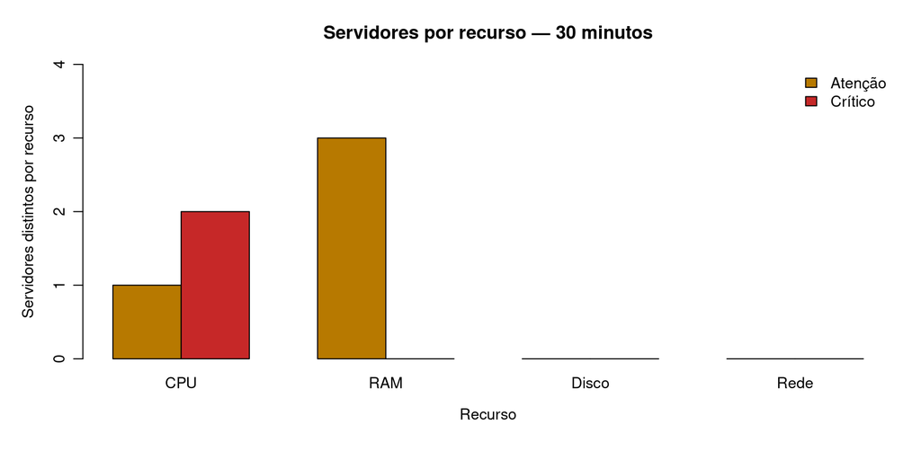

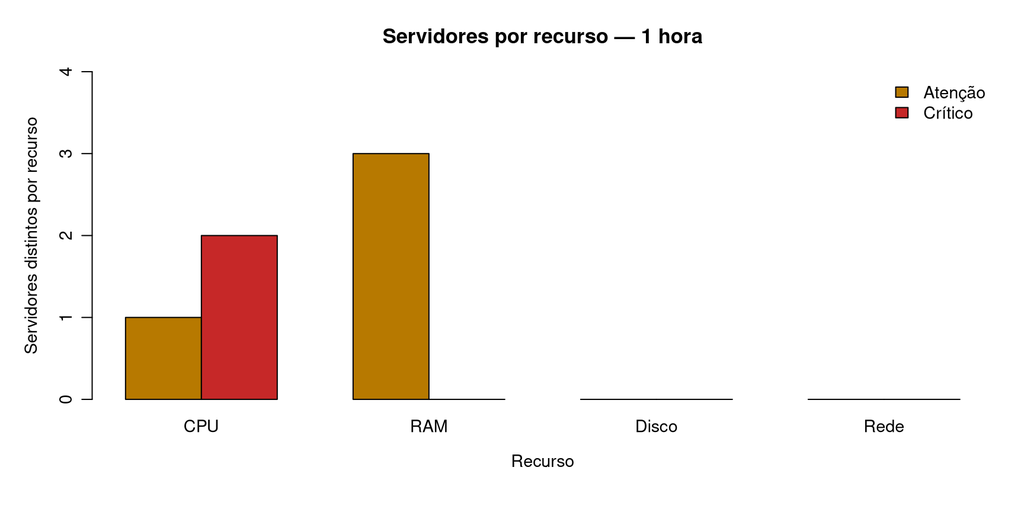

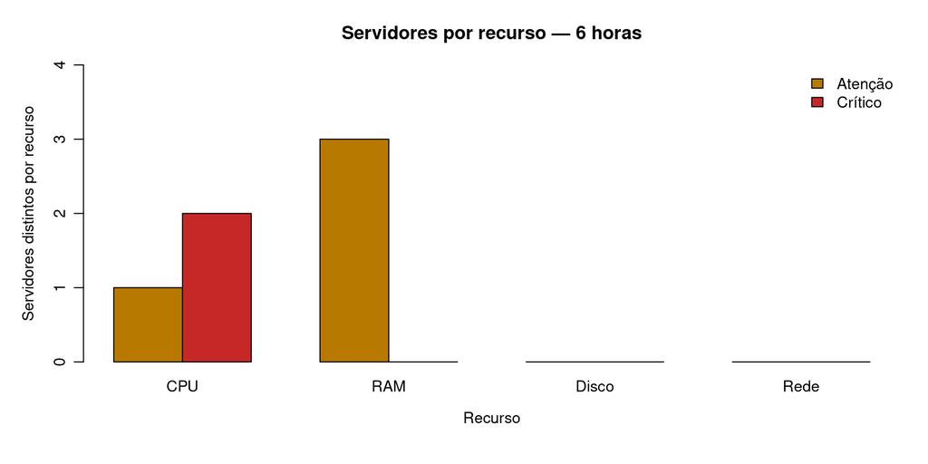

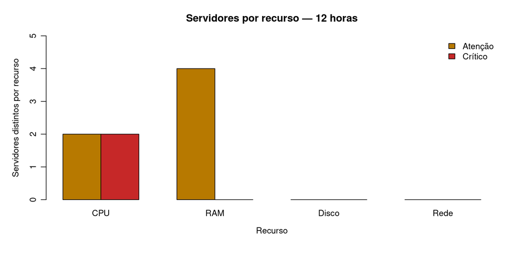

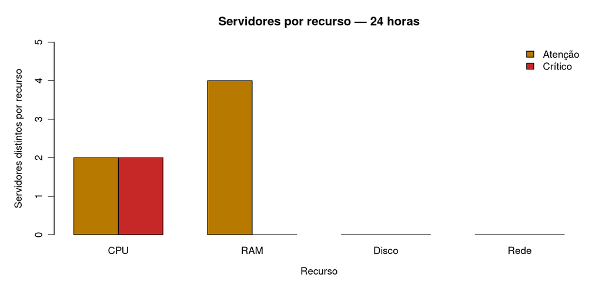

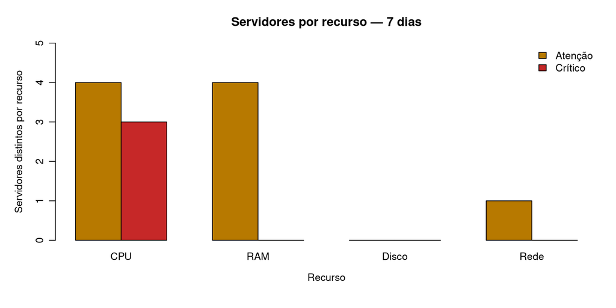

```r
recursos_analisados = c("CPU", "RAM", "Disco", "Rede")
barras_periodo = data.frame()
for (perfil_atual in perfis_analisados) {
  for (periodo_atual in names(periodos)) {
    dados_periodo = selecionar_periodo(periodo_atual, perfil_atual)
    for (recurso in recursos_analisados) {
      metricas_recurso = switch(recurso, CPU = "cpu_percent", RAM = "ram_percent",
        Disco = "disk_percent", Rede = c("net_errors", "net_drops"))
      quantidade_atencao = 0
      quantidade_criticos = 0
      for (mac_atual in unique(dados_periodo$mac)) {
        dados_servidor_periodo = dados_periodo[dados_periodo$mac == mac_atual, ]
        maior_gravidade = 1
        for (metrica_atual in metricas_recurso) {
          coluna_situacao = paste0("estado_", metrica_atual)
          gravidades_recurso = match(dados_servidor_periodo[[coluna_situacao]], ordem_gravidade)
          maior_gravidade = max(maior_gravidade, gravidades_recurso)
        }
        if (maior_gravidade == 2) quantidade_atencao = quantidade_atencao + 1
        if (maior_gravidade == 3) quantidade_criticos = quantidade_criticos + 1
      }
      barras_periodo = rbind(barras_periodo, data.frame(periodo = periodo_atual,
        perfil = perfil_atual, recurso = recurso, atencao = quantidade_atencao, critico = quantidade_criticos))
    }
  }
}

# Exibe os seis gráficos gerais. A tabela também contém os três perfis.
for (periodo_atual in names(periodos)) {
  barras_periodo_atual = barras_periodo[barras_periodo$periodo == periodo_atual & barras_periodo$perfil == "Todos", ]
  contagem_recursos = rbind(Atenção = barras_periodo_atual$atencao, Crítico = barras_periodo_atual$critico)
  colnames(contagem_recursos) = barras_periodo_atual$recurso
  barplot(contagem_recursos, beside = TRUE, col = c("#B77900", "#C62828"),
    ylim = c(0, max(4, contagem_recursos + 1)), main = paste("Servidores por recurso —", periodo_atual),
    ylab = "Servidores distintos por recurso", xlab = "Recurso",
    legend.text = rownames(contagem_recursos), args.legend = list(x = "topright", bty = "n"))
}
```

```r
knitr::kable(barras_periodo[barras_periodo$perfil == "Todos", ])
```

| periodo | perfil | recurso | atencao | critico |
| --- | --- | --- | --- | --- |
| 30 minutos | Todos | CPU | 1 | 2 |
| 30 minutos | Todos | RAM | 3 | 0 |
| 30 minutos | Todos | Disco | 0 | 0 |
| 30 minutos | Todos | Rede | 0 | 0 |
| 1 hora | Todos | CPU | 1 | 2 |
| 1 hora | Todos | RAM | 3 | 0 |
| 1 hora | Todos | Disco | 0 | 0 |
| 1 hora | Todos | Rede | 0 | 0 |
| 6 horas | Todos | CPU | 1 | 2 |
| 6 horas | Todos | RAM | 3 | 0 |
| 6 horas | Todos | Disco | 0 | 0 |
| 6 horas | Todos | Rede | 0 | 0 |
| 12 horas | Todos | CPU | 2 | 2 |
| 12 horas | Todos | RAM | 4 | 0 |
| 12 horas | Todos | Disco | 0 | 0 |
| 12 horas | Todos | Rede | 0 | 0 |
| 24 horas | Todos | CPU | 2 | 2 |
| 24 horas | Todos | RAM | 4 | 0 |
| 24 horas | Todos | Disco | 0 | 0 |
| 24 horas | Todos | Rede | 0 | 0 |
| 7 dias | Todos | CPU | 4 | 3 |
| 7 dias | Todos | RAM | 4 | 0 |
| 7 dias | Todos | Disco | 0 | 0 |
| 7 dias | Todos | Rede | 1 | 0 |

As barras ficam lado a lado, como na dash. Para cada recurso, o servidor aparece na maior gravidade do período. Erros e descartes da mesma interface entram juntos em Rede sem contar o servidor duas vezes. Um servidor pode aparecer em CPU e RAM; somar recursos não dá servidores únicos.

Condições ativas às 20h30 e episódios do período são contagens diferentes. Um incidente pode ter terminado antes do instante final e ainda aparecer no resumo da semana.

## 11 Evolução dos servidores em alerta

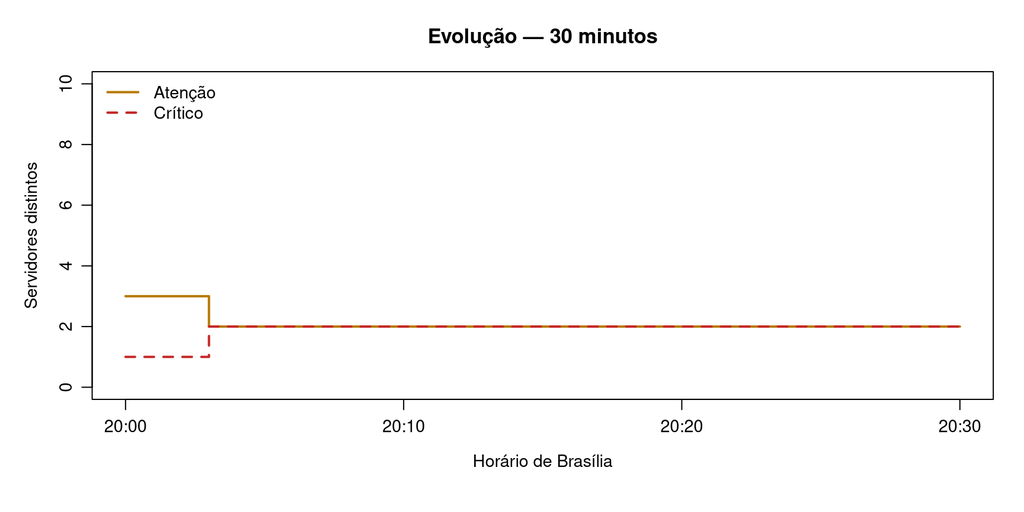

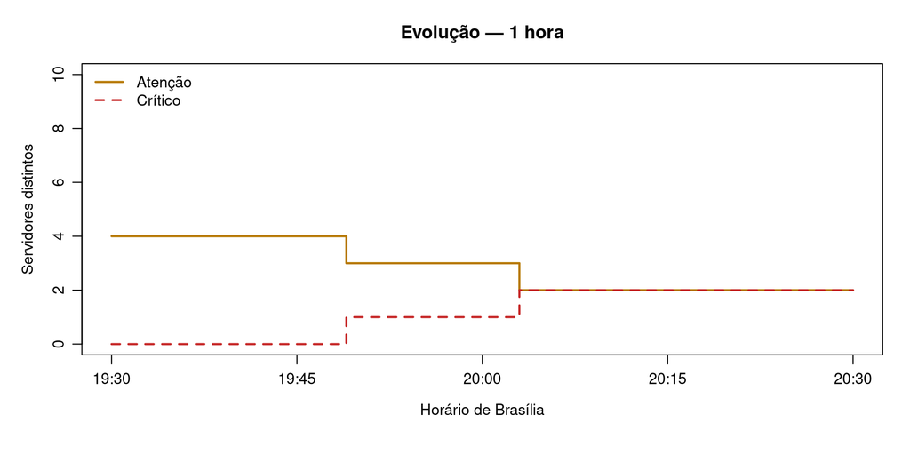

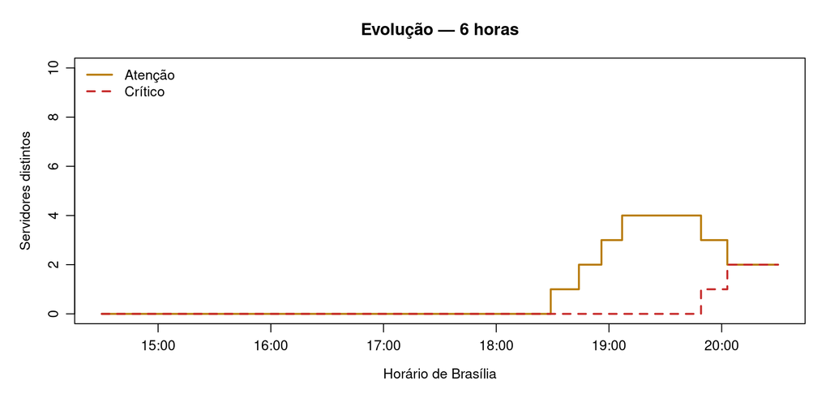

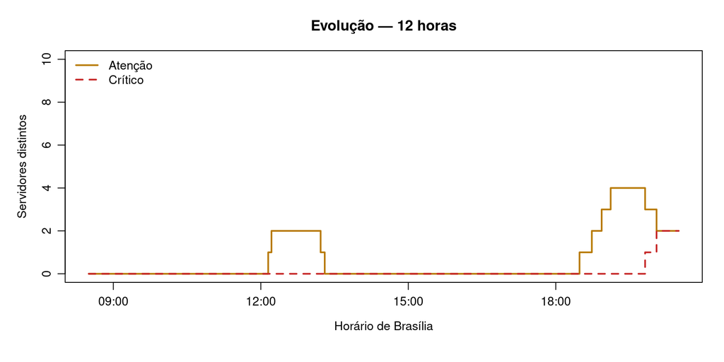

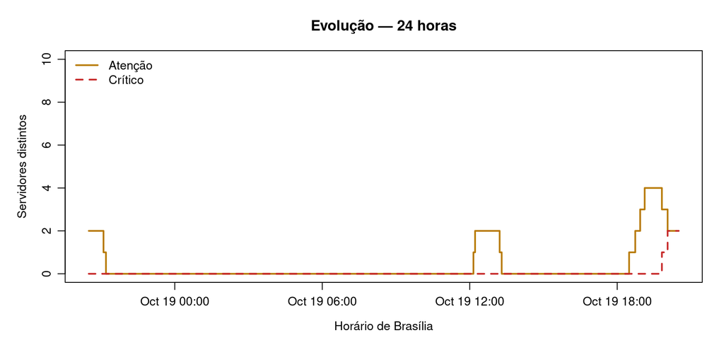

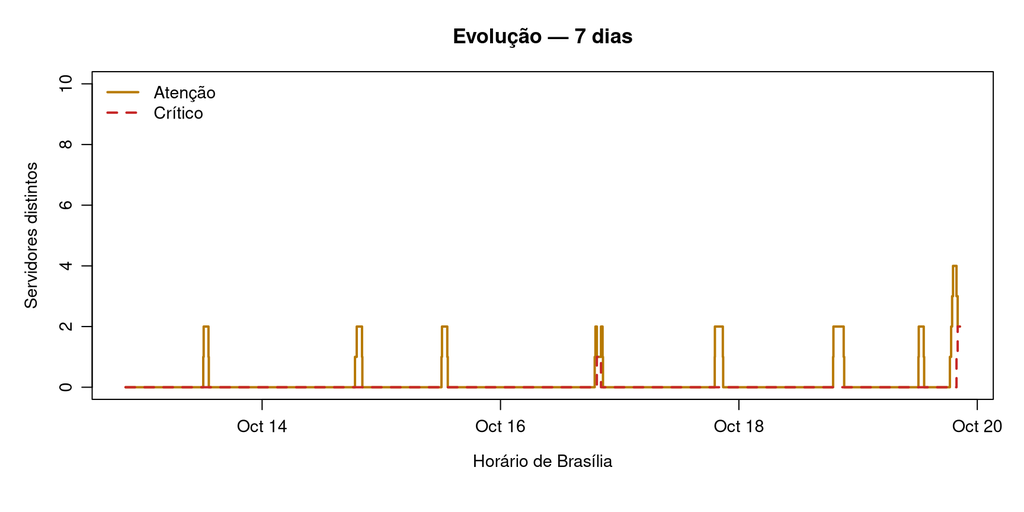

```r
# Tamanho das margens e dos rótulos do gráfico.
par(mar = c(5.5, 4.5, 3.5, 1.5), mgp = c(2.5, 0.8, 0), cex = 0.9)
evolucao = data.frame(instante = horarios_semana, atencao = 0, critico = 0)
for (mac_atual in cadastro_servidores$mac) {
  situacoes_servidor = historico_servidores$situacao[historico_servidores$mac == mac_atual]
  evolucao$atencao = evolucao$atencao + as.integer(situacoes_servidor == "Atenção")
  evolucao$critico = evolucao$critico + as.integer(situacoes_servidor == "Crítico")
}
for (periodo_atual in names(periodos)) {
  evolucao_periodo = evolucao[evolucao$instante >= horario_final - periodos[periodo_atual] * 60, ]
  plot(evolucao_periodo$instante, evolucao_periodo$atencao, type = "s", col = "#B77900", lwd = 2,
    ylim = c(0, 10), xlab = "Horário de Brasília", ylab = "Servidores distintos",
    main = paste("Evolução —", periodo_atual))
  lines(evolucao_periodo$instante, evolucao_periodo$critico, type = "s", col = "#C62828", lwd = 2, lty = 2)
  legend("topleft", c("Atenção", "Crítico"), col = c("#B77900", "#C62828"),
    lty = c(1, 2), lwd = 2, bty = "n")
}
```

```r
# Servidores com alerta no trecho de domingo incluído nas últimas 24 horas.
domingo_24h = historico_servidores[historico_servidores$instante >= horario_final - 1440 * 60 &
  historico_servidores$instante < converter_horario("2026-10-19 00:00:00") & historico_servidores$situacao != "Normal", ]
knitr::kable(data.frame(servidor = unique(domingo_24h$servidor)))
```

| servidor |
| --- |
| cart-api-07 |
| pay-db-02 |

```r
# O filtro inclui os incidentes ainda ativos, mesmo iniciados antes dele.
incidentes_30m = incidentes[incidentes$inicio <= horario_final &
  (is.na(incidentes$fim) | incidentes$fim > horario_final - 30 * 60), ]
knitr::kable(incidentes_30m[c("servidor", "metrica", "inicio", "escalada", "pico", "fim", "severidade")], digits = 2)
```

|  | servidor | metrica | inicio | escalada | pico | fim | severidade |
| --- | --- | --- | --- | --- | --- | --- | --- |
| 16 | cart-api-12 | cpu_percent | 2026-10-19 18:29:00 | NA | 78 | NA | Atenção |
| 17 | pay-db-02 | ram_percent | 2026-10-19 18:44:00 | NA | 79 | NA | Atenção |
| 18 | cart-api-07 | cpu_percent | 2026-10-19 18:56:00 | 2026-10-19 20:03:00 | 94 | NA | Crítico |
| 19 | pay-api-04 | cpu_percent | 2026-10-19 19:07:00 | 2026-10-19 19:49:00 | 95 | NA | Crítico |
| 20 | cart-api-07 | ram_percent | 2026-10-19 19:24:00 | NA | 81 | NA | Atenção |
| 21 | pay-api-04 | ram_percent | 2026-10-19 19:29:00 | NA | 83 | NA | Atenção |

A linha em degraus muda no minuto registrado. Quando um servidor passa de atenção para crítico, ele sai de uma contagem e entra na outra. A contagem em atenção pode cair enquanto a gravidade aumenta.

| Período | Pergunta apoiada |
| --- | --- |
| 30 minutos | Como ocorreu a escalada crítica final? |
| 1 hora | Quais mudanças antecederam o estado atual? |
| 6 horas | Como o jantar se diferencia da tarde? |
| 12 horas | Como almoço e jantar se comparam? |
| 24 horas | Qual parte do episódio de domingo ainda aparece? |
| 7 dias | Quais episódios se repetem e quais são diferentes? |

Os filtros mostram partes da mesma história. Como são só sete dias simulados, não podemos afirmar que esse padrão se repete numa operação real. Um registro por minuto também pode deixar de mostrar acontecimentos mais rápidos.

### 11.1 Distribuição e persistência

```r
# Tamanho das margens e dos rótulos do gráfico.
par(mar = c(5.5, 4.5, 3.5, 1.5), mgp = c(2.5, 0.8, 0), cex = 0.9)
estatisticas_servidores = data.frame()
for (nome_servidor in cadastro_servidores$servidor) {
  dados_servidor = historico_servidores[historico_servidores$servidor == nome_servidor, ]
  estatisticas_servidores = rbind(estatisticas_servidores, data.frame(servidor = nome_servidor,
    cpu_media = mean(dados_servidor$cpu_percent), cpu_mediana = median(dados_servidor$cpu_percent),
    cpu_p95 = as.numeric(quantile(dados_servidor$cpu_percent, 0.95)), cpu_max = max(dados_servidor$cpu_percent),
    ram_max = max(dados_servidor$ram_percent), amostras_atencao = sum(dados_servidor$situacao == "Atenção"),
    amostras_criticas = sum(dados_servidor$situacao == "Crítico")))
}
knitr::kable(estatisticas_servidores, digits = 2)
```

| servidor | cpu_media | cpu_mediana | cpu_p95 | cpu_max | ram_max | amostras_atencao | amostras_criticas |
| --- | --- | --- | --- | --- | --- | --- | --- |
| cart-api-07 | 44.88 | 42.99 | 50.87 | 94.00 | 81.00 | 201 | 28 |
| cart-api-12 | 39.87 | 37.99 | 45.77 | 80.00 | 63.39 | 222 | 0 |
| cart-api-02 | 49.99 | 48.72 | 55.86 | 84.00 | 82.00 | 214 | 0 |
| cart-api-09 | 38.98 | 37.60 | 44.86 | 80.00 | 58.67 | 85 | 0 |
| pay-db-02 | 59.01 | 57.94 | 65.07 | 67.05 | 84.00 | 307 | 0 |
| pay-api-04 | 43.47 | 41.99 | 49.38 | 95.00 | 83.00 | 42 | 42 |
| pay-api-06 | 52.08 | 50.52 | 57.98 | 96.00 | 62.71 | 118 | 50 |
| catalog-api-03 | 47.17 | 45.44 | 53.54 | 83.00 | 60.56 | 288 | 0 |
| catalog-api-05 | 44.15 | 43.09 | 50.20 | 52.14 | 67.46 | 0 | 0 |
| catalog-api-08 | 37.48 | 36.42 | 43.55 | 45.47 | 55.61 | 0 | 0 |

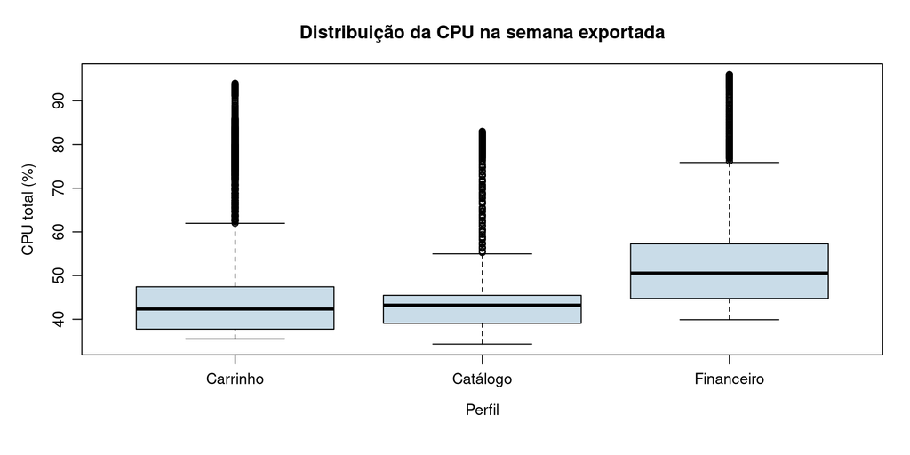

```r
boxplot(cpu_percent ~ perfil, data = historico_servidores, col = "#C9DCE8",
  main = "Distribuição da CPU na semana exportada", xlab = "Perfil", ylab = "CPU total (%)")
```

A média e a mediana ajudam a resumir o uso de CPU, mas podem esconder alertas curtos. O percentil 95 mostra o valor abaixo do qual ficam cerca de 95% dos registros. O máximo mostra o maior uso observado. Os pontos altos do boxplot fazem parte dos episódios simulados e não foram retirados. Cada minuto é um registro da mesma semana, e não um experimento separado.

## 12 Investigação técnica dos recursos

### 12.1 Referência temporal da tela de detalhe

No detalhe, gráficos e incidentes usam o período escolhido. CPU/RAM em destaque, memória atual, processos, containers e volumes atuais continuam representando 20h30. Os medidores de CPU lógica usam médias do período. A previsão do detalhe usa a semana toda. Assim, o período descreve a evolução dos sinais, enquanto os valores atuais mostram a situação às 20h30.

### 12.2 CPU total, CPU lógica e memória

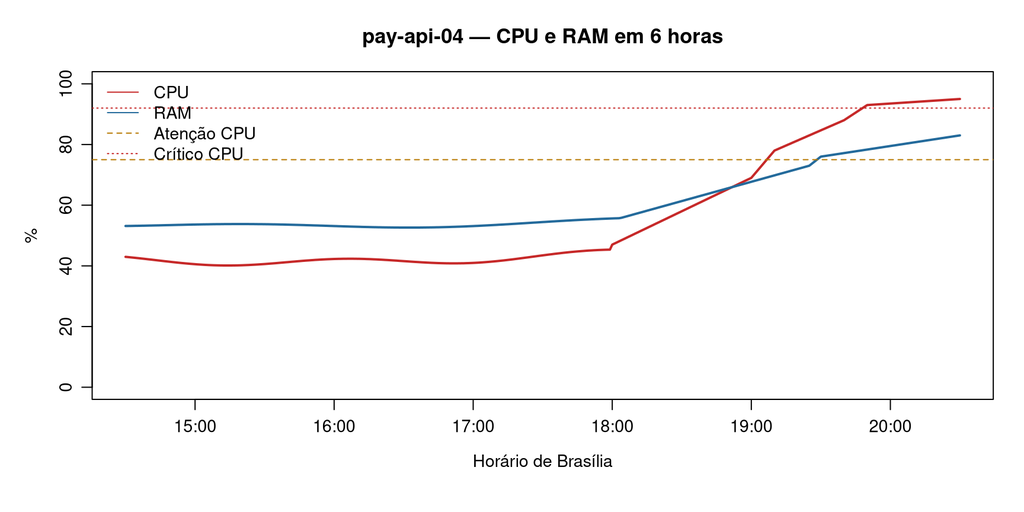

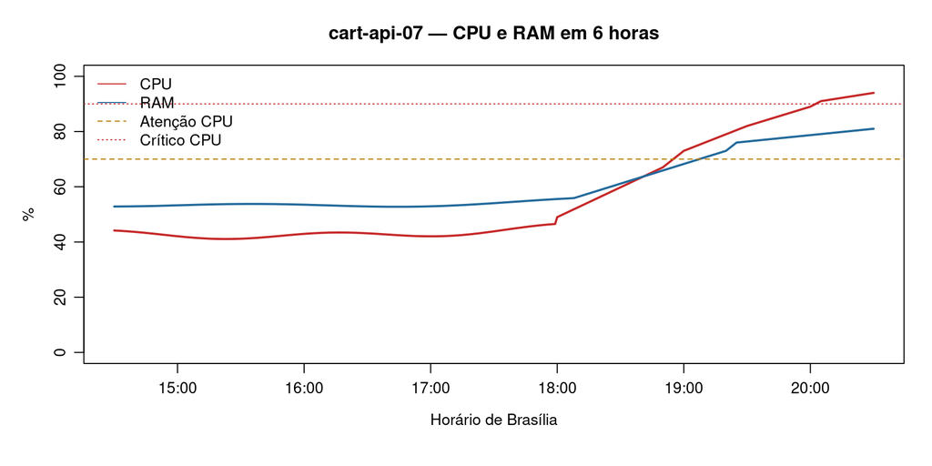

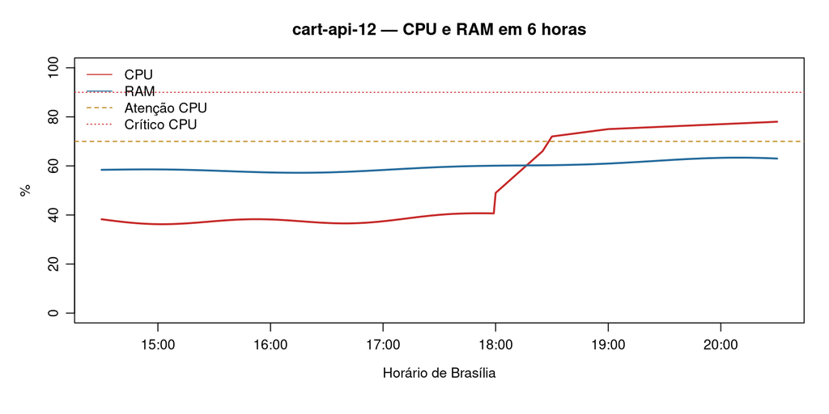

```r
# Tamanho das margens e dos rótulos do gráfico.
par(mar = c(5.5, 4.5, 3.5, 1.5), mgp = c(2.5, 0.8, 0), cex = 0.9)
for (nome_servidor in c("pay-api-04", "cart-api-07", "cart-api-12")) {
  dados_servidor = historico_servidores[historico_servidores$servidor == nome_servidor & historico_servidores$instante >= horario_final - 360 * 60, ]
  limite_cpu = limites_alerta[limites_alerta$perfil == dados_servidor$perfil[1] & limites_alerta$metrica == "cpu_percent", ]
  plot(dados_servidor$instante, dados_servidor$cpu_percent, type = "l", lwd = 2, col = "#C62828", ylim = c(0, 100),
    main = paste(nome_servidor, "— CPU e RAM em 6 horas"), xlab = "Horário de Brasília", ylab = "%")
  lines(dados_servidor$instante, dados_servidor$ram_percent, col = "#236A9B", lwd = 2)
  abline(h = c(limite_cpu$atencao, limite_cpu$critico), lty = c(2, 3), col = c("#B77900", "#C62828"))
  legend("topleft", c("CPU", "RAM", "Atenção CPU", "Crítico CPU"),
    col = c("#C62828", "#236A9B", "#B77900", "#C62828"), lty = c(1, 1, 2, 3), bty = "n")
}
```

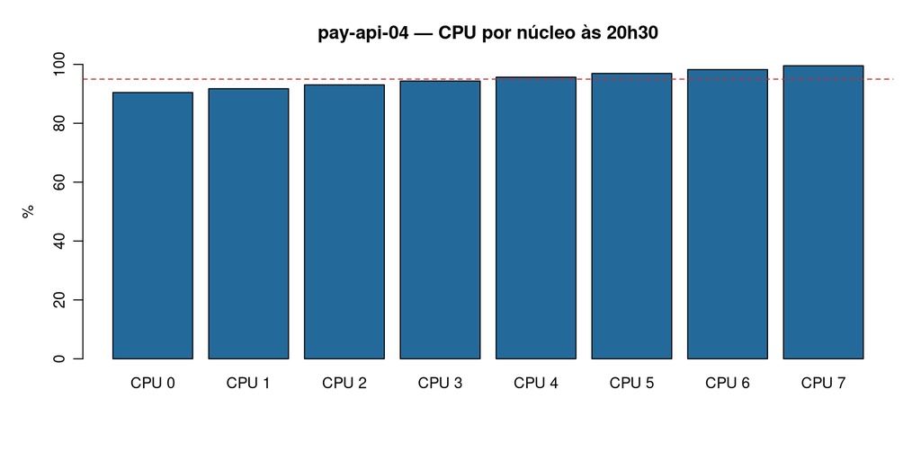

```r
# Valores por núcleo e médias de cada período.
medias_nucleos = data.frame()
for (indice_servidor in seq_len(nrow(cadastro_servidores))) {
  servidor_atual = cadastro_servidores[indice_servidor, ]
  colunas_nucleos = paste0("cpu_percent_percpu_", 0:(servidor_atual$cpu_logicas - 1))
  dados_servidor = historico_servidores[historico_servidores$mac == servidor_atual$mac, ]
  for (periodo_atual in names(periodos)) {
    dados_periodo = dados_servidor[dados_servidor$instante >= horario_final - periodos[periodo_atual] * 60, ]
    medias_por_nucleo = numeric(length(colunas_nucleos))
    for (indice_nucleo in seq_along(colunas_nucleos)) {
      medias_por_nucleo[indice_nucleo] = mean(dados_periodo[[colunas_nucleos[indice_nucleo]]])
    }
    medias_nucleos = rbind(medias_nucleos, data.frame(servidor = servidor_atual$servidor,
      periodo = periodo_atual, cpu = 0:(servidor_atual$cpu_logicas - 1), media_percent = round(medias_por_nucleo, 2)))
  }
}
coleta_pay_api04 = dados_atuais[dados_atuais$servidor == "pay-api-04", ]
colunas_nucleos = paste0("cpu_percent_percpu_", 0:(coleta_pay_api04$cpu_count_logical - 1))
valores_nucleos = as.numeric(coleta_pay_api04[1, colunas_nucleos])
barplot(valores_nucleos, names.arg = paste0("CPU ", 0:(length(valores_nucleos) - 1)), ylim = c(0, 100),
  col = "#236A9B", main = "pay-api-04 — CPU por núcleo às 20h30", ylab = "%")
abline(h = coleta_pay_api04$cpu_percent, col = "#C62828", lty = 2)
```

```r
knitr::kable(medias_nucleos[medias_nucleos$servidor == "pay-api-04", ], digits = 2)
```

|  | servidor | periodo | cpu | media_percent |
| --- | --- | --- | --- | --- |
| 241 | pay-api-04 | 30 minutos | 0 | 89.02 |
| 242 | pay-api-04 | 30 minutos | 1 | 90.52 |
| 243 | pay-api-04 | 30 minutos | 2 | 92.01 |
| 244 | pay-api-04 | 30 minutos | 3 | 93.50 |
| 245 | pay-api-04 | 30 minutos | 4 | 95.00 |
| 246 | pay-api-04 | 30 minutos | 5 | 96.49 |
| 247 | pay-api-04 | 30 minutos | 6 | 97.98 |
| 248 | pay-api-04 | 30 minutos | 7 | 99.48 |
| 249 | pay-api-04 | 1 hora | 0 | 86.14 |
| 250 | pay-api-04 | 1 hora | 1 | 87.85 |
| 251 | pay-api-04 | 1 hora | 2 | 89.55 |
| 252 | pay-api-04 | 1 hora | 3 | 91.25 |
| 253 | pay-api-04 | 1 hora | 4 | 92.95 |
| 254 | pay-api-04 | 1 hora | 5 | 94.65 |
| 255 | pay-api-04 | 1 hora | 6 | 96.36 |
| 256 | pay-api-04 | 1 hora | 7 | 98.06 |
| 257 | pay-api-04 | 6 horas | 0 | 49.24 |
| 258 | pay-api-04 | 6 horas | 1 | 51.19 |
| 259 | pay-api-04 | 6 horas | 2 | 53.14 |
| 260 | pay-api-04 | 6 horas | 3 | 55.09 |
| 261 | pay-api-04 | 6 horas | 4 | 57.04 |
| 262 | pay-api-04 | 6 horas | 5 | 58.99 |
| 263 | pay-api-04 | 6 horas | 6 | 60.94 |
| 264 | pay-api-04 | 6 horas | 7 | 62.89 |
| 265 | pay-api-04 | 12 horas | 0 | 43.02 |
| 266 | pay-api-04 | 12 horas | 1 | 44.99 |
| 267 | pay-api-04 | 12 horas | 2 | 46.97 |
| 268 | pay-api-04 | 12 horas | 3 | 48.94 |
| 269 | pay-api-04 | 12 horas | 4 | 50.92 |
| 270 | pay-api-04 | 12 horas | 5 | 52.89 |
| 271 | pay-api-04 | 12 horas | 6 | 54.87 |
| 272 | pay-api-04 | 12 horas | 7 | 56.84 |
| 273 | pay-api-04 | 24 horas | 0 | 39.01 |
| 274 | pay-api-04 | 24 horas | 1 | 41.00 |
| 275 | pay-api-04 | 24 horas | 2 | 42.99 |
| 276 | pay-api-04 | 24 horas | 3 | 44.97 |
| 277 | pay-api-04 | 24 horas | 4 | 46.96 |
| 278 | pay-api-04 | 24 horas | 5 | 48.95 |
| 279 | pay-api-04 | 24 horas | 6 | 50.93 |
| 280 | pay-api-04 | 24 horas | 7 | 52.92 |
| 281 | pay-api-04 | 7 dias | 0 | 36.47 |
| 282 | pay-api-04 | 7 dias | 1 | 38.47 |
| 283 | pay-api-04 | 7 dias | 2 | 40.47 |
| 284 | pay-api-04 | 7 dias | 3 | 42.47 |
| 285 | pay-api-04 | 7 dias | 4 | 44.47 |
| 286 | pay-api-04 | 7 dias | 5 | 46.46 |
| 287 | pay-api-04 | 7 dias | 6 | 48.46 |
| 288 | pay-api-04 | 7 dias | 7 | 50.46 |

```r
knitr::kable(dados_atuais[c("servidor", "ram_total", "ram_percent", "ram_available", "ram_used")], digits = 2)
```

|  | servidor | ram_total | ram_percent | ram_available | ram_used |
| --- | --- | --- | --- | --- | --- |
| 10081 | cart-api-02 | 16 | 64 | 5.76 | 10.24 |
| 20162 | cart-api-07 | 16 | 81 | 3.04 | 12.96 |
| 30243 | cart-api-09 | 16 | 57 | 6.88 | 9.12 |
| 40324 | cart-api-12 | 16 | 63 | 5.92 | 10.08 |
| 50405 | pay-db-02 | 32 | 79 | 6.72 | 25.28 |
| 60486 | pay-api-04 | 16 | 83 | 2.72 | 13.28 |
| 70567 | pay-api-06 | 16 | 62 | 6.08 | 9.92 |
| 80648 | catalog-api-03 | 16 | 59 | 6.56 | 9.44 |
| 90729 | catalog-api-05 | 64 | 66 | 21.76 | 42.24 |
| 100810 | catalog-api-08 | 16 | 55 | 7.20 | 8.80 |

O gráfico por núcleo representa um instante; a tabela de médias representa o período e permite comparar os medidores do detalhe. Os dois usam a mesma distribuição exportada. O `catalog-api-05` tem 64 GB de RAM; seu percentual de ocupação é interpretado junto da quantidade disponível em GB. CPU e RAM crescem juntas neste exemplo porque o cenário foi montado assim. Isso não prova que uma causou o aumento da outra.

### 12.3 Carga, swap e I/O

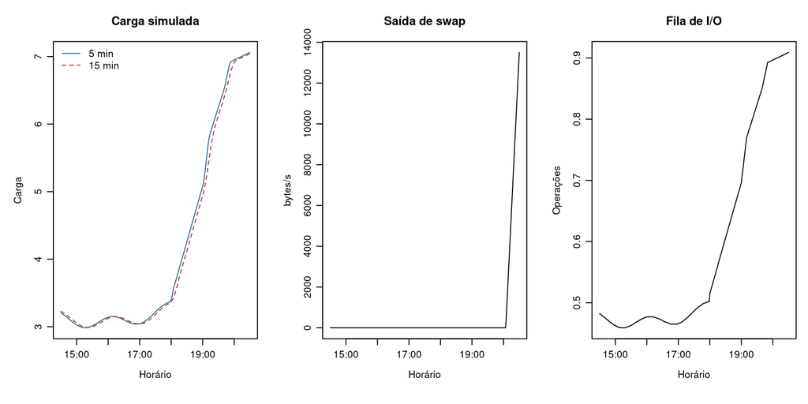

```r
dados_pay_api04 = historico_servidores[historico_servidores$servidor == "pay-api-04" & historico_servidores$instante >= horario_final - 360 * 60, ]
par(mfrow = c(1, 3), mar = c(5.5, 4.5, 3.5, 1), mgp = c(2.5, 0.8, 0))
plot(dados_pay_api04$instante, dados_pay_api04$load_avg_5, type = "l", col = "#236A9B", main = "Carga simulada",
     xlab = "Horário", ylab = "Carga")
lines(dados_pay_api04$instante, dados_pay_api04$load_avg_15, col = "#C62828", lty = 2)
legend("topleft", c("5 min", "15 min"), col = c("#236A9B", "#C62828"), lty = c(1, 2), bty = "n")
plot(dados_pay_api04$instante, dados_pay_api04$swap_out_bytes_s, type = "l", main = "Saída de swap", xlab = "Horário", ylab = "bytes/s")
plot(dados_pay_api04$instante, dados_pay_api04$io_queue, type = "l", main = "Fila de I/O", xlab = "Horário", ylab = "Operações")
```

```r
par(mfrow = c(1, 1))

knitr::kable(dados_atuais[c("servidor", "load_avg_5", "load_avg_15", "swap_percent",
  "swap_total_gb", "swap_used_gb", "swap_free_gb", "swap_in_bytes_s", "swap_out_bytes_s",
  "io_dispositivo", "io_read_ms", "io_write_ms", "io_queue", "io_read_iops", "io_write_iops")], digits = 3)
```

|  | servidor | load_avg_5 | load_avg_15 | swap_percent | swap_total_gb | swap_used_gb | swap_free_gb | swap_in_bytes_s | swap_out_bytes_s | io_dispositivo | io_read_ms | io_write_ms | io_queue | io_read_iops | io_write_iops |
| --- | --- | --- | --- | --- | --- | --- | --- | --- | --- | --- | --- | --- | --- | --- | --- |
| 10081 | cart-api-02 | 4.238 | 4.227 | 10.0 | 4 | 0.400 | 3.600 | 0 | 0 | nvme0n1 | 2.19 | 3.07 | 0.597 | 171 | 70 |
| 20162 | cart-api-07 | 6.976 | 6.931 | 19.1 | 4 | 0.764 | 3.236 | 48000 | 4500 | nvme0n1 | 2.93 | 4.00 | 0.901 | 276 | 116 |
| 30243 | cart-api-09 | 3.432 | 3.447 | 10.0 | 4 | 0.400 | 3.600 | 0 | 0 | nvme0n1 | 1.97 | 2.80 | 0.507 | 152 | 64 |
| 40324 | cart-api-12 | 5.798 | 5.786 | 10.0 | 4 | 0.400 | 3.600 | 0 | 0 | nvme0n1 | 2.61 | 3.60 | 0.770 | 243 | 100 |
| 50405 | pay-db-02 | 4.850 | 4.885 | 17.7 | 8 | 1.416 | 6.584 | 32000 | 0 | nvme1n1 | 4.15 | 5.28 | 1.625 | 388 | 508 |
| 60486 | pay-api-04 | 7.060 | 7.042 | 20.5 | 4 | 0.820 | 3.180 | 64000 | 13500 | nvme0n1 | 2.95 | 4.03 | 0.909 | 271 | 112 |
| 70567 | pay-api-06 | 4.310 | 4.298 | 10.0 | 4 | 0.400 | 3.600 | 0 | 0 | nvme0n1 | 2.21 | 3.10 | 0.606 | 178 | 76 |
| 80648 | catalog-api-03 | 4.020 | 4.017 | 10.0 | 4 | 0.400 | 3.600 | 0 | 0 | nvme0n1 | 2.13 | 3.00 | 0.573 | 183 | 74 |
| 90729 | catalog-api-05 | 3.806 | 3.835 | 10.0 | 8 | 0.800 | 7.200 | 0 | 0 | nvme0n1 | 2.07 | 2.92 | 0.548 | 163 | 66 |
| 100810 | catalog-api-08 | 3.212 | 3.241 | 10.0 | 4 | 0.400 | 3.600 | 0 | 0 | nvme0n1 | 1.91 | 2.72 | 0.483 | 137 | 59 |

A carga de 5 e 15 minutos usa médias móveis simples da série simulada de 1 minuto. Essa é a regra do cenário, diferente do cálculo real do Linux. Swap e I/O também são valores simulados.

Uma carga alta pode envolver tarefas esperando CPU ou disco. Já a swap pode continuar ocupada depois de um período de maior uso. Por isso, olhamos esses sinais em conjunto. Para saber o impacto no serviço, também precisamos do tempo de resposta e dos erros da aplicação.

### 12.4 Volumes, espaço livre e inodes

```r
knitr::kable(volumes_finais[c("servidor", "volume", "total_gb", "usado_gb", "livre_gb",
                             "ocupacao_percent", "inodes_usados_percent")], digits = 2)
```

|  | servidor | volume | total_gb | usado_gb | livre_gb | ocupacao_percent | inodes_usados_percent |
| --- | --- | --- | --- | --- | --- | --- | --- |
| 20161 | cart-api-07 | /dados | 200 | 116.00 | 84.00 | 58.00 | 24.00 |
| 20162 | cart-api-07 | / | 120 | 42.96 | 77.04 | 35.80 | 16.00 |
| 40323 | cart-api-12 | /dados | 200 | 106.00 | 94.00 | 53.00 | 24.70 |
| 40324 | cart-api-12 | / | 120 | 45.80 | 74.20 | 38.17 | 16.95 |
| 60485 | cart-api-02 | /dados | 200 | 108.00 | 92.00 | 54.00 | 25.40 |
| 60486 | cart-api-02 | / | 120 | 49.28 | 70.72 | 41.07 | 17.90 |
| 80647 | cart-api-09 | /dados | 200 | 104.00 | 96.00 | 52.00 | 26.10 |
| 80648 | cart-api-09 | / | 120 | 52.14 | 67.86 | 43.45 | 18.85 |
| 100809 | pay-db-02 | /dados | 200 | 142.00 | 58.00 | 71.00 | 26.89 |
| 100810 | pay-db-02 | / | 160 | 71.55 | 88.45 | 44.72 | 19.80 |
| 120971 | pay-api-04 | /dados | 200 | 132.00 | 68.00 | 66.00 | 27.50 |
| 120972 | pay-api-04 | / | 120 | 54.40 | 65.60 | 45.33 | 20.75 |
| 141133 | pay-api-06 | /dados | 200 | 128.00 | 72.00 | 64.00 | 28.20 |
| 141134 | pay-api-06 | / | 120 | 55.60 | 64.40 | 46.33 | 21.70 |
| 161295 | catalog-api-03 | /dados | 200 | 126.00 | 74.00 | 63.00 | 28.90 |
| 161296 | catalog-api-03 | / | 120 | 58.08 | 61.92 | 48.40 | 22.65 |
| 181457 | catalog-api-05 | /dados | 500 | 385.00 | 115.00 | 77.00 | 30.23 |
| 181458 | catalog-api-05 | / | 120 | 61.50 | 58.50 | 51.25 | 23.60 |
| 201619 | catalog-api-08 | /dados | 200 | 98.00 | 102.00 | 49.00 | 30.30 |
| 201620 | catalog-api-08 | / | 120 | 64.64 | 55.36 | 53.87 | 24.55 |

`/dados` e `/` são volumes diferentes e permanecem separados. O percentual de inodes indica a ocupação das estruturas usadas para registrar arquivos. A simulação não fornece as contagens absolutas de inodes; por isso não estimamos dias até seu esgotamento. O dispositivo de I/O é outra identificação, sem assumir que ele é o mesmo recurso que cada volume.

### 12.5 Rede no sábado e tráfego

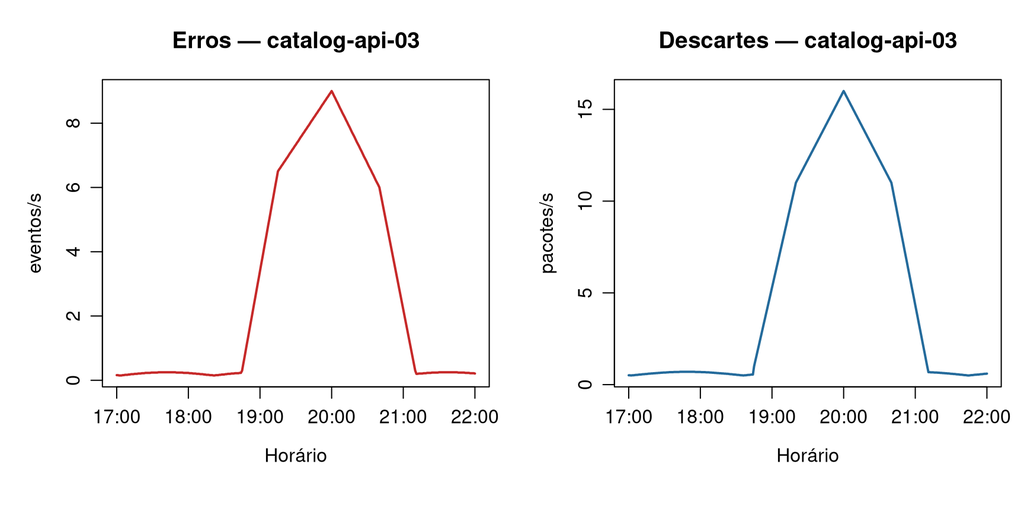

```r
dados_rede_sabado = historico_servidores[
  historico_servidores$servidor == "catalog-api-03" &
  historico_servidores$instante >= converter_horario("2026-10-17 17:00:00") &
  historico_servidores$instante <= converter_horario("2026-10-17 22:00:00"), ]
par(mfrow = c(1, 2), mar = c(5.5, 4.5, 3.5, 1), mgp = c(2.5, 0.8, 0))
plot(dados_rede_sabado$instante, dados_rede_sabado$net_errors, type = "l", col = "#C62828", lwd = 2,
  main = "Erros — catalog-api-03", xlab = "Horário", ylab = "eventos/s")
plot(dados_rede_sabado$instante, dados_rede_sabado$net_drops, type = "l", col = "#236A9B", lwd = 2,
  main = "Descartes — catalog-api-03", xlab = "Horário", ylab = "pacotes/s")
```

```r
par(mfrow = c(1, 1))
knitr::kable(dados_atuais[c("servidor", "rede_interface", "rede_recv_mb_s", "rede_sent_mb_s",
  "rede_errin_s", "rede_errout_s", "rede_dropin_s", "rede_dropout_s")], digits = 3)
```

|  | servidor | rede_interface | rede_recv_mb_s | rede_sent_mb_s | rede_errin_s | rede_errout_s | rede_dropin_s | rede_dropout_s |
| --- | --- | --- | --- | --- | --- | --- | --- | --- |
| 10081 | cart-api-02 | eth0 | 5.48 | 2.148 | 0.143 | 0.047 | 0.448 | 0.242 |
| 20162 | cart-api-07 | eth0 | 8.81 | 3.406 | 0.165 | 0.055 | 0.429 | 0.231 |
| 30243 | cart-api-09 | eth0 | 4.49 | 1.774 | 0.188 | 0.062 | 0.332 | 0.178 |
| 40324 | cart-api-12 | eth0 | 7.37 | 2.862 | 0.173 | 0.057 | 0.384 | 0.206 |
| 50405 | pay-db-02 | eth0 | 4.90 | 1.770 | 0.112 | 0.038 | 0.455 | 0.245 |
| 60486 | pay-api-04 | eth0 | 7.00 | 2.490 | 0.188 | 0.062 | 0.370 | 0.200 |
| 70567 | pay-api-06 | eth0 | 4.41 | 1.602 | 0.143 | 0.047 | 0.436 | 0.234 |
| 80648 | catalog-api-03 | eth0 | 3.05 | 1.830 | 0.173 | 0.057 | 0.410 | 0.220 |
| 90729 | catalog-api-05 | eth0 | 2.90 | 1.740 | 0.165 | 0.055 | 0.403 | 0.217 |
| 100810 | catalog-api-08 | eth0 | 2.50 | 1.500 | 0.150 | 0.050 | 0.442 | 0.238 |

O episódio de rede termina antes do instante final. Erros e descartes são apresentados separadamente e identificados por interface e direção. Tráfego está em MB/s decimais; erros e descartes têm unidades próprias. Esses dados não são percentuais de rede nem contagens de pedidos perdidos. Estado da interface e taxas de pacotes fazem parte do catálogo, mas não estão presentes nesta base.

### 12.6 Processos, containers e OOM

```r
knitr::kable(processos_atuais[processos_atuais$servidor == "pay-api-04",
  c("servidor", "pid", "nome", "estado", "cpu_percent", "ram_gb")], digits = 3)
```

|  | servidor | pid | nome | estado | cpu_percent | ram_gb |
| --- | --- | --- | --- | --- | --- | --- |
| 16 | pay-api-04 | 2405 | node · pay-api-04 | Executando | 243.2 | 3.851 |
| 17 | pay-api-04 | 2417 | pay-worker | Executando | 91.2 | 1.594 |
| 18 | pay-api-04 | 2463 | coretrace-agent | Em espera | 3.8 | 0.066 |

```r
knitr::kable(containers_atuais[containers_atuais$servidor == "pay-api-04",
  c("servidor", "id", "nome", "estado", "cpu_percent", "ram_gb", "leitura_bytes_s", "escrita_bytes_s")], digits = 3)
```

|  | servidor | id | nome | estado | cpu_percent | ram_gb | leitura_bytes_s | escrita_bytes_s |
| --- | --- | --- | --- | --- | --- | --- | --- | --- |
| 16 | pay-api-04 | demo-6-1 | pay-api-04-app | Executando | 288.80 | 4.515 | 6467200 | 2878200 |
| 17 | pay-api-04 | demo-6-2 | pay-api-04-worker | Executando | 114.00 | 2.125 | 2707200 | 1193400 |
| 18 | pay-api-04 | demo-6-3 | pay-api-04-agent | Executando | 4.56 | 0.106 | 225600 | 70200 |

```r
knitr::kable(cadastro_servidores[c("servidor", "perfil", "docker")])
```

| servidor | perfil | docker |
| --- | --- | --- |
| cart-api-07 | Carrinho | TRUE |
| cart-api-12 | Carrinho | TRUE |
| cart-api-02 | Carrinho | TRUE |
| cart-api-09 | Carrinho | TRUE |
| pay-db-02 | Financeiro | TRUE |
| pay-api-04 | Financeiro | TRUE |
| pay-api-06 | Financeiro | TRUE |
| catalog-api-03 | Catálogo | FALSE |
| catalog-api-05 | Catálogo | FALSE |
| catalog-api-08 | Catálogo | FALSE |

```r
# Quantidade de consumidores no instante final.
knitr::kable(data.frame(tipo = c("Processos", "Containers"),
  quantidade = c(nrow(processos_atuais), nrow(containers_atuais))))
```

| tipo | quantidade |
| --- | --- |
| Processos | 30 |
| Containers | 21 |

```r
oom_periodos = data.frame()
for (periodo_atual in names(periodos)) {
  dados_periodo = selecionar_periodo(periodo_atual)
  if (any(is.na(dados_periodo$ram_oom_kills))) stop("Há valores ausentes na coluna de OOM.")
  oom_periodos = rbind(oom_periodos, data.frame(periodo = periodo_atual,
    ocorrencias_oom = sum(dados_periodo$ram_oom_kills)))
}
knitr::kable(oom_periodos)
```

| periodo | ocorrencias_oom |
| --- | --- |
| 30 minutos | 0 |
| 1 hora | 0 |
| 6 horas | 0 |
| 12 horas | 0 |
| 24 horas | 0 |
| 7 dias | 0 |

Os processos e containers representam os consumidores às 20h30. O uso de CPU segue a convenção de 100% por CPU lógica, podendo passar de 100%. Um processo pode estar dentro de um container; somar os dois níveis pode duplicar consumo. No perfil Catálogo, Docker não é monitorado.

Não há ocorrências de OOM na semana simulada. Esse resultado descreve o cenário e não representa uma medição do contador real do Linux.

## 13 Previsão de capacidade: geral e detalhe

A previsão utiliza duas janelas de histórico. Na geral, a previsão usa apenas os pontos horários do período selecionado e exige pelo menos três pontos e 24 horas. No detalhe, usa os pontos horários da semana inteira. Nos dois casos, só há previsão quando o crescimento é suficiente; nesta simulação, o mínimo é 0,25 ponto percentual por dia.

O crescimento diário é calculado pela diferença entre a primeira e a última ocupação da janela, dividida pela duração em dias. A geral arredonda o prazo para cima; o detalhe apresenta uma casa decimal e não oferece previsão de um volume já no limite crítico.

```r
# Tamanho das margens e dos rótulos do gráfico.
par(mar = c(5.5, 4.5, 3.5, 1.5), mgp = c(2.5, 0.8, 0), cex = 0.9)
previsoes_geral = data.frame()
previsoes_detalhe = data.frame()
for (indice_servidor in seq_len(nrow(cadastro_servidores))) {
  servidor_atual = cadastro_servidores[indice_servidor, ]
  dados_servidor = historico_servidores[historico_servidores$mac == servidor_atual$mac, ]
  # A dash amostra o histórico a cada 60 minutos a partir do início da semana.
  coletas_por_hora = dados_servidor[seq(1, nrow(dados_servidor), by = 60), ]
  limite_disco = limites_alerta[limites_alerta$perfil == servidor_atual$perfil & limites_alerta$metrica == "disk_percent", ]
  ocupacao_atual = tail(dados_servidor$disk_percent, 1)
  crescimento_diario_semana = (tail(coletas_por_hora$disk_percent, 1) - coletas_por_hora$disk_percent[1]) / 7
  prazo_detalhe = NA_real_
  if (crescimento_diario_semana >= 0.25 && ocupacao_atual < limite_disco$critico) {
    prazo_detalhe = round((limite_disco$critico - ocupacao_atual) / crescimento_diario_semana, 1)
  }
  previsoes_detalhe = rbind(previsoes_detalhe, data.frame(servidor = servidor_atual$servidor,
    perfil = servidor_atual$perfil, volume = "/dados", periodo_calculo = "7 dias",
    ocupacao_percent = ocupacao_atual, crescimento_pp_dia = round(crescimento_diario_semana, 3),
    limite_critico = limite_disco$critico, dias = prazo_detalhe))

  for (periodo_atual in names(periodos)) {
    coletas_horarias_periodo = coletas_por_hora[coletas_por_hora$instante >= horario_final - periodos[periodo_atual] * 60, ]
    duracao_dias = as.numeric(difftime(tail(coletas_horarias_periodo$instante, 1), coletas_horarias_periodo$instante[1], units = "days"))
    crescimento_diario = NA_real_
    prazo_previsto = NA_real_
    situacao_previsao = "Dados insuficientes"
    if (nrow(coletas_horarias_periodo) >= 3 && duracao_dias >= 1) {
      crescimento_diario = (tail(coletas_horarias_periodo$disk_percent, 1) - coletas_horarias_periodo$disk_percent[1]) / duracao_dias
      situacao_previsao = "Sem tendência"
      if (crescimento_diario > 0 && crescimento_diario >= 0.25) {
        prazo_bruto = (limite_disco$critico - tail(coletas_horarias_periodo$disk_percent, 1)) / crescimento_diario
        # Limita erros de precisão antes de arredondar o prazo para cima.
        prazo_previsto = max(0, ceiling(round(prazo_bruto, 8)))
        situacao_previsao = "Com previsão"
      }
    }
    previsoes_geral = rbind(previsoes_geral, data.frame(servidor = servidor_atual$servidor,
      perfil = servidor_atual$perfil, periodo = periodo_atual, pontos = nrow(coletas_horarias_periodo), crescimento_pp_dia = crescimento_diario,
      dias = prazo_previsto, resultado = situacao_previsao))
  }
}

# O card geral escolhe o menor prazo disponível entre os servidores do perfil.
cards_previsao = data.frame()
for (perfil_atual in perfis_analisados) {
  for (periodo_atual in names(periodos)) {
    previsoes_periodo = previsoes_geral[previsoes_geral$periodo == periodo_atual, ]
    if (perfil_atual != "Todos") previsoes_periodo = previsoes_periodo[previsoes_periodo$perfil == perfil_atual, ]
    previsoes_disponiveis = previsoes_periodo[!is.na(previsoes_periodo$dias), ]
    servidor_previsao = ""
    dias_previstos = NA_real_
    situacao_previsao = if (periodos[periodo_atual] < 1440) "Dados insuficientes" else "Sem tendência"
    if (nrow(previsoes_disponiveis) > 0) {
      menor_previsao = previsoes_disponiveis[which.min(previsoes_disponiveis$dias), ]
      servidor_previsao = menor_previsao$servidor
      dias_previstos = menor_previsao$dias
      situacao_previsao = "Com previsão"
    }
    cards_previsao = rbind(cards_previsao, data.frame(perfil = perfil_atual,
      periodo = periodo_atual, servidor = servidor_previsao, dias = dias_previstos, resultado = situacao_previsao))
  }
}
knitr::kable(previsoes_geral[previsoes_geral$servidor == "catalog-api-05", ], digits = 3)
```

|  | servidor | perfil | periodo | pontos | crescimento_pp_dia | dias | resultado |
| --- | --- | --- | --- | --- | --- | --- | --- |
| 49 | catalog-api-05 | Catálogo | 30 minutos | 1 | NA | NA | Dados insuficientes |
| 50 | catalog-api-05 | Catálogo | 1 hora | 2 | NA | NA | Dados insuficientes |
| 51 | catalog-api-05 | Catálogo | 6 horas | 7 | NA | NA | Dados insuficientes |
| 52 | catalog-api-05 | Catálogo | 12 horas | 13 | NA | NA | Dados insuficientes |
| 53 | catalog-api-05 | Catálogo | 24 horas | 25 | 1.5 | 12 | Com previsão |
| 54 | catalog-api-05 | Catálogo | 7 dias | 169 | 1.5 | 12 | Com previsão |

```r
knitr::kable(previsoes_detalhe, digits = 3)
```

| servidor | perfil | volume | periodo_calculo | ocupacao_percent | crescimento_pp_dia | limite_critico | dias |
| --- | --- | --- | --- | --- | --- | --- | --- |
| cart-api-07 | Carrinho | /dados | 7 dias | 58 | 0.04 | 95 | NA |
| cart-api-12 | Carrinho | /dados | 7 dias | 53 | 0.04 | 95 | NA |
| cart-api-02 | Carrinho | /dados | 7 dias | 54 | 0.04 | 95 | NA |
| cart-api-09 | Carrinho | /dados | 7 dias | 52 | 0.04 | 95 | NA |
| pay-db-02 | Financeiro | /dados | 7 dias | 71 | 0.04 | 95 | NA |
| pay-api-04 | Financeiro | /dados | 7 dias | 66 | 0.04 | 95 | NA |
| pay-api-06 | Financeiro | /dados | 7 dias | 64 | 0.04 | 95 | NA |
| catalog-api-03 | Catálogo | /dados | 7 dias | 63 | 0.04 | 95 | NA |
| catalog-api-05 | Catálogo | /dados | 7 dias | 77 | 1.50 | 95 | 12 |
| catalog-api-08 | Catálogo | /dados | 7 dias | 49 | 0.04 | 95 | NA |

```r
knitr::kable(cards_previsao)
```

| perfil | periodo | servidor | dias | resultado |
| --- | --- | --- | --- | --- |
| Todos | 30 minutos |  | NA | Dados insuficientes |
| Todos | 1 hora |  | NA | Dados insuficientes |
| Todos | 6 horas |  | NA | Dados insuficientes |
| Todos | 12 horas |  | NA | Dados insuficientes |
| Todos | 24 horas | catalog-api-05 | 12 | Com previsão |
| Todos | 7 dias | catalog-api-05 | 12 | Com previsão |
| Carrinho | 30 minutos |  | NA | Dados insuficientes |
| Carrinho | 1 hora |  | NA | Dados insuficientes |
| Carrinho | 6 horas |  | NA | Dados insuficientes |
| Carrinho | 12 horas |  | NA | Dados insuficientes |
| Carrinho | 24 horas |  | NA | Sem tendência |
| Carrinho | 7 dias |  | NA | Sem tendência |
| Financeiro | 30 minutos |  | NA | Dados insuficientes |
| Financeiro | 1 hora |  | NA | Dados insuficientes |
| Financeiro | 6 horas |  | NA | Dados insuficientes |
| Financeiro | 12 horas |  | NA | Dados insuficientes |
| Financeiro | 24 horas |  | NA | Sem tendência |
| Financeiro | 7 dias |  | NA | Sem tendência |
| Catálogo | 30 minutos |  | NA | Dados insuficientes |
| Catálogo | 1 hora |  | NA | Dados insuficientes |
| Catálogo | 6 horas |  | NA | Dados insuficientes |
| Catálogo | 12 horas |  | NA | Dados insuficientes |
| Catálogo | 24 horas | catalog-api-05 | 12 | Com previsão |
| Catálogo | 7 dias | catalog-api-05 | 12 | Com previsão |

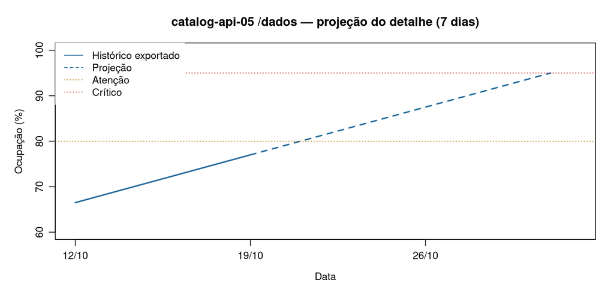

```r
previsao_catalogo = previsoes_detalhe[previsoes_detalhe$servidor == "catalog-api-05", ]
dados_servidor = historico_servidores[historico_servidores$servidor == "catalog-api-05", ]
plot(dados_servidor$instante, dados_servidor$disk_percent, type = "l", lwd = 2, col = "#236A9B",
  xlim = c(inicio_semana, horario_final + 13 * 86400), ylim = c(60, 100),
  main = "catalog-api-05 /dados — projeção do detalhe (7 dias)",
  xlab = "Data", ylab = "Ocupação (%)", xaxt = "n")
marcas_data = seq(inicio_semana, horario_final + 13 * 86400, by = "7 days")
axis(1, at = marcas_data, labels = format(marcas_data, "%d/%m", tz = "America/Sao_Paulo"))
lines(c(horario_final, horario_final + previsao_catalogo$dias * 86400), c(previsao_catalogo$ocupacao_percent, previsao_catalogo$limite_critico),
  lty = 2, lwd = 2, col = "#236A9B")
abline(h = c(80, previsao_catalogo$limite_critico), col = c("#B77900", "#C62828"), lty = 3)
legend("topleft", c("Histórico exportado", "Projeção", "Atenção", "Crítico"),
  col = c("#236A9B", "#236A9B", "#B77900", "#C62828"), lty = c(1, 2, 3, 3),
  bty = "o", bg = "white", box.col = "white")
```

Com a semana inteira, `(95 - 77) / 1,5 = 12 dias` até atingir 95%. O crescimento é de 1,5 ponto percentual por dia, equivalente a 7,5 GB/dia num volume de 500 GB. Com operador `>`, estar exatamente em 95% ainda não é ultrapassar o limite crítico. A ocupação de 77% também está abaixo da atenção de 80%: a previsão apoia planejamento e não é um alerta ativo.

Os 12 dias não são repetidos automaticamente nos filtros curtos. Neles, a geral informa dados insuficientes. No detalhe, a previsão continua semanal. A projeção depende de crescimento constante definido no cenário; limpeza, expansão e mudança da demanda podem invalidá-la em uma operação real.

## 14 Justificativa das métricas essenciais

Usamos a metodologia USE como referência para pensar em três perguntas: quanto do recurso está em uso, se há trabalho esperando por ele e se há erros. As métricas do CoreTrace ajudam nessas perguntas, mas não cobrem todos os aspectos da metodologia. A escolha das métricas obrigatórias faz parte da proposta do produto.

| Grupo do catálogo | Pergunta apoiada | O que foi analisado e qual é o limite |
| --- | --- | --- |
| CPU total e por CPU lógica | Quanto processamento é usado e onde se concentra? | Classificação total, valores por núcleo e médias por período; não comprovam lentidão da aplicação |
| RAM percentual, disponível e total | Qual a ocupação e a margem em GB? | Capacidades e valores exportados, incluindo 64 GB no catalog-api-05; a relação entre usada e disponível segue a convenção da simulação |
| OOM | Houve encerramento por falta de memória? | Valores informados e iguais a zero; não testa o contador real do Linux nem reinício |
| Disco percentual e livre | Quanto está ocupado e quanto resta? | Histórico e valores atuais por volume, com tendência de capacidade; não mede desempenho por si só |
| Inodes | Ainda há capacidade de registrar arquivos? | Percentuais exportados por volume; não há contagens absolutas nem previsão de esgotamento |
| Tempo estimado e fila de I/O | Há atividade acompanhada de espera? | Valores sintéticos por dispositivo e operação; não são tempo de resposta da aplicação nem validação de limites reais |
| Swap percentual, entrada e saída | Há ocupação e movimentação? | Valores do gerador, representam a ocupação e movimentação definidas para o cenário |
| Carga de 5 e 15 minutos | A demanda persiste? | Médias móveis da série simulada de 1 minuto; não reproduzem o cálculo real do Linux |
| Rede | Qual o tráfego e quais ocorrências há por interface? | Tráfego, erros e descartes exportados; estado da interface e taxas de pacotes não foram fornecidos nos CSVs |
| Processos e containers | Quem acompanha o consumo do servidor? | Listas atuais de consumidores, com CPU e RAM; sem vínculo comprovado entre processo e container nem histórico desses consumidores |

A necessidade de cada métrica depende do ambiente e das perguntas de investigação. Modos de CPU, frequência, interrupções, trocas de contexto e demais campos não exportados continuam como itens do catálogo, sem análise numérica neste estudo. O produto deve aceitar não aplicabilidade e a seleção pode ser revista conforme a necessidade.

## 15 Como a dashboard apoia as decisões

| Elemento | Pergunta | Decisão apoiada | Limitação |
| --- | --- | --- | --- |
| Cards de servidores no período | Quais servidores chegaram a atenção ou crítico? | Priorizar a investigação do intervalo | A maior gravidade histórica não é necessariamente o estado atual |
| Alertas do período | Quantos episódios por componente ocorreram na janela? | Localizar ocorrências, inclusive recuperadas | Não equivale a servidores, condições atuais ou tickets |
| Alertas ativos e valores atuais | O que continua fora do normal às 20h30? | Investigar os componentes ainda afetados | Não garante disponibilidade da aplicação |
| Previsão de capacidade | Em quanto tempo o volume chegaria ao limite? | Avaliar limpeza ou expansão | Geral e detalhe usam janelas diferentes; depende da tendência |
| Evolução temporal | Como as contagens mudaram? | Investigar início, escalada e recuperação | Resolução de um minuto perde eventos menores |
| Barras por recurso no período | Onde ocorreram condições de maior gravidade? | Direcionar a investigação | O mesmo servidor pode aparecer em mais de um recurso |
| Detalhes e consumidores | Que outros sinais acompanham o episódio? | Formular e conferir hipóteses | Dois sinais variarem juntos não explica, sozinho, a causa |

No cenário de delivery, os perfis ajudam a separar carrinho, pagamentos e catálogo. O histórico também permite comparar almoço, jantar e campanha. Um perfil não é automaticamente mais importante que outro: a prioridade depende da gravidade do problema e do impacto no serviço.

CPU, RAM, disco e rede permitem acompanhar os problemas definidos no cenário. Carga, swap, I/O, processos e containers ajudam a investigar. Isso não cobre todo problema de uma operação de delivery. Dependendo da necessidade, também é preciso acompanhar tempo de resposta, erros da aplicação, pedidos, pagamentos, banco de dados e filas.

## 16 Conclusão

Na semana simulada, os servidores apresentam episódios de aumento de CPU, memória e ocorrências de rede. Parte deles se recupera antes do instante final. Às 20h30, quatro servidores continuam afetados, com dois críticos, dois em atenção e seis condições de alerta ativas.

A evolução temporal e os resumos por período ajudam a distinguir episódios recuperados dos que continuam ativos. O detalhamento por recurso, núcleo, volume e consumidor acrescenta contexto à investigação. No armazenamento, a ocupação de 77% do volume de 500 GB do `catalog-api-05` ainda está abaixo do limite de atenção, mas o crescimento de 1,5 ponto percentual por dia indica 12 dias até atingir 95%, considerando a semana inteira.

Com essas métricas, conseguimos analisar os episódios da simulação. Para tirar conclusões sobre uma operação real e saber se houve impacto em pedidos ou pagamentos, seriam necessários dados reais dos servidores e da aplicação.

## 17 Referências e origem dos dados

- Cenário narrativo: `cenario-fornecido.txt`.
- Dados: arquivos CSV da pasta indicada em `pasta_csv`, gerados pela simulação do CoreTrace.
- Fórmulas da simulação: `website/public/scripts/cenario/cenario-coretrace-7dias.js` e `detalhamento-servidor.js`.
- Regras da geral: `dashboardDados.js` e `dashboardSimulacao.js`; os limites exportados são referência do código, não consulta ao banco.
- [Brendan Gregg — The USE Method](https://www.brendangregg.com/usemethod.html): utilização, saturação e erros; não define as obrigatoriedades do produto.
- [psutil — memória](https://psutil.readthedocs.io/stable/#psutil.virtual_memory): distinções entre os campos de memória de uma coleta real.

## 18 Exportação dos resultados

As tabelas calculadas são salvas em uma pasta separada dos arquivos de entrada.

```r
dir.create("resultados-analise", showWarnings = FALSE)
salvar_resultado = function(tabela, nome) {
  write.csv(tabela, file.path("resultados-analise", nome), row.names = FALSE,
            na = "", fileEncoding = "UTF-8")
}
salvar_resultado(resumo_dados, "resumo-dados.csv")
salvar_resultado(incidentes_jantar, "incidentes-jantar.csv")
salvar_resultado(cards_periodo, "cards-periodos-perfis.csv")
salvar_resultado(barras_periodo, "barras-periodos-perfis.csv")
salvar_resultado(evolucao, "evolucao.csv")
salvar_resultado(incidentes, "incidentes.csv")
salvar_resultado(alertas_ativos, "alertas-ativos.csv")
salvar_resultado(indicadores_finais, "indicadores-finais.csv")
salvar_resultado(dados_atuais[c("servidor", "mac", "perfil", "cpu_percent", "ram_percent", "ram_total",
  "ram_used", "ram_available", "situacao")], "servidores-finais.csv")
salvar_resultado(medias_nucleos, "medias-nucleos-periodos.csv")
salvar_resultado(estatisticas_servidores, "estatisticas.csv")
salvar_resultado(previsoes_geral, "previsoes-geral.csv")
salvar_resultado(previsoes_detalhe, "previsoes-detalhe.csv")
salvar_resultado(cards_previsao, "cards-previsao.csv")
salvar_resultado(oom_periodos, "oom-periodos.csv")
```